# Healthcare Analytics: Risk-Stratified Outcomes and Forward Revenue Projection

**Author:** Olivia Cai · **Date:** May 2026

**Tech stack:** pandas, NumPy, scikit-learn, statsmodels, scipy, factor_analyzer, seaborn

**TL;DR.** A connected chain of techniques (data screening → PCA → K-Means → rule-based stratification → A/B testing → bootstrap + Monte Carlo) applied to a synthetic 100K-patient EHR cohort. Headline finding: high-risk patients (Charlson index ≥ 2, age ≥ 65) have **3.5x** the 30-day readmission rate of low-risk patients (19.9% vs 5.7%, p < 1e-15, 95% CI on the gap [+10.7 pp, +17.6 pp]), but **no** statistically significant per-stay cost gap. The actionable lever is readmission, not cost.

## Project Overview

This project analyzes a synthetic Electronic Health Records (EHR) dataset modeled on adult US patients from 2018 to 2024. The dataset is calibrated against CDC NHANES (vitals), CDC NCHS (disease prevalence), and CMS (hospitalization and readmission) benchmarks. The goal is to translate raw clinical data into actionable healthcare insights using a connected chain of statistical techniques.

**Project flow:**

1. Screen and clean the data, then engineer clinically meaningful features.
2. Merge the patients and outcomes datasets to focus on the 6,725 hospitalized patients that pass the data quality screen.
3. Apply Principal Component Analysis (PCA) to test for latent structure in the patient feature space. KMO = 0.511 and 7 components needed for 69% cumulative variance, a documented diagnostic finding that this synthetic dataset has limited shared variance for PCA to consolidate.
4. Apply K-Means clustering on the principal components. Silhouette peaks at 0.143 (problematic band) and the partition mostly recovers the engineered high_cost_flag rather than discovering distinct personas, so we pivot to a clinically-defined risk stratification (charlson_index >= 2 and age >= 65 for High, the inverse for Low, Medium otherwise), which produces a clean monotonic gradient on demographics, vitals, and outcomes.
5. Use A/B testing (Welch's t-tests and two-proportion z-tests) on the rule-based strata to verify they differ on cost and readmission outcomes, identify confounders, and stratify on `comorbidity_count` to confirm robustness.
6. Use bootstrap resampling to quantify uncertainty in our point estimates and Monte Carlo simulation to project forward to next year's revenue under a 10% volume-growth scenario.
7. Translate the analytical findings into business recommendations.

The narrative moves from the broad population to outcome-linked patients to specific patient segments, covering both breadth and depth.

## 1. Imports and Setup

### 1.1 Install non-default packages

```python
# Install factor_analyzer
!pip install factor_analyzer --quiet
```

### 1.2 Imports

```python
# Core data handling
import pandas as pd
import numpy as np

# Visualization
import matplotlib.pyplot as plt
import matplotlib.cm as cm
import seaborn as sns
import math

# Statistical functions
from scipy import stats
from scipy.stats import ttest_ind, mannwhitneyu, chi2_contingency, norm

# Hypothesis testing for proportions and multicollinearity diagnostics
from statsmodels.stats.proportion import proportions_ztest
from statsmodels.stats.outliers_influence import variance_inflation_factor

# Machine learning utilities
from sklearn.preprocessing import StandardScaler
from sklearn.decomposition import PCA
from sklearn.cluster import KMeans
from sklearn.metrics import silhouette_score, silhouette_samples

# PCA suitability tests
from factor_analyzer.factor_analyzer import calculate_kmo, calculate_bartlett_sphericity

# Display settings so wide DataFrames print cleanly
pd.set_option('display.max_columns', 60)
pd.set_option('display.width', 200)
```

### 1.3 Random seed

```python
# Set random seed
RANDOM_SEED = 3099

# Seed the legacy numpy RNG so any function reading the global state is reproducible
np.random.seed(RANDOM_SEED)

# Seed the modern numpy Generator used by the bootstrap and Monte Carlo helpers
rng = np.random.default_rng(seed=RANDOM_SEED)

print(f'Random seed set to {RANDOM_SEED}')
```

```
Random seed set to 3099
```

### 1.4 Load datasets

```python
# Portable data path handling. Works locally (from the repo root) and on Colab.
import os
from pathlib import Path

try:
    # Colab path: mount Drive only when actually running on Colab
    import google.colab  # noqa: F401
    from google.colab import drive
    drive.mount('/content/drive')
    DATA_DIR = Path('/content/drive/MyDrive/DSO 545/Final')
except ImportError:
    # Local / GitHub clone: assume data lives alongside this notebook in a `data/` folder
    DATA_DIR = Path('data')

print(f'Using DATA_DIR = {DATA_DIR}')
assert DATA_DIR.exists(), f'DATA_DIR does not exist: {DATA_DIR}. Place patients.csv and patient_outcome.csv in this folder.'
```

```
Using DATA_DIR = data
```

```python
# Read both CSVs into pandas DataFrames using the portable DATA_DIR set above
patient_df = pd.read_csv(DATA_DIR / 'patients.csv')
outcome_df = pd.read_csv(DATA_DIR / 'patient_outcome.csv')
```

## 2. Data Overview and Initial Screening

Before any modeling, we describe the structure of each dataset, identify missing values and outliers, and run logical and physiological data-quality checks. Healthcare decisions are high stakes, so confirming the data is trustworthy is a prerequisite to every downstream analysis.

### 2.1 Dataset structure

```python
# Preview the patients DataFrame to see the shape of a single record
patient_df.head()
```

|  | patient_id | age | gender | bmi | systolic_bp | diastolic_bp | heart_rate | temperature_f | smoking_status | alcohol_use | exercise_level | insurance_type | charlson_index | dx_hypertension | dx_type2_diabetes | dx_hyperlipidemia | dx_obesity | dx_coronary_artery_disease | dx_heart_failure | dx_atrial_fibrillation | dx_chronic_kidney_disease | dx_copd | dx_asthma | dx_depression | dx_anxiety | dx_hypothyroidism | dx_osteoarthritis | dx_type1_diabetes |
| --- | --- | --- | --- | --- | --- | --- | --- | --- | --- | --- | --- | --- | --- | --- | --- | --- | --- | --- | --- | --- | --- | --- | --- | --- | --- | --- | --- | --- |
| 0 | P0000001 | 66 | M | 23.5 | 148 | 81 | 64 | 98.4 | former | light | moderate | medicare | 2 | 0 | 0 | 1 | 0 | 0 | 0 | 0 | 1 | 0 | 0 | 0 | 0 | 0 | 1 | 0 |
| 1 | P0000002 | 75 | M | 24.8 | 158 | 86 | 45 | 99.5 | never | moderate | moderate | commercial | 1 | 1 | 1 | 0 | 1 | 0 | 0 | 0 | 0 | 0 | 1 | 0 | 0 | 0 | 1 | 0 |
| 2 | P0000003 | 82 | M | 17.8 | 135 | 57 | 90 | 98.2 | never | light | moderate | medicare | 3 | 0 | 0 | 0 | 1 | 1 | 0 | 0 | 1 | 0 | 0 | 0 | 0 | 0 | 0 | 0 |
| 3 | P0000004 | 73 | F | 28.1 | 118 | 83 | 102 | 98.9 | former | moderate | moderate | medicaid | 0 | 1 | 0 | 1 | 1 | 0 | 0 | 0 | 0 | 0 | 0 | 0 | 0 | 0 | 0 | 0 |
| 4 | P0000005 | 86 | F | 30.6 | 156 | 81 | 56 | 98.7 | never | heavy | sedentary | medicare | 0 | 1 | 0 | 1 | 1 | 0 | 0 | 0 | 0 | 0 | 1 | 1 | 0 | 1 | 0 | 0 |

```python
# Preview the patient outcomes DataFrame to see the shape of a single hospital stay
outcome_df.head()
```

|  | patient_id | admission_date | discharge_date | length_of_stay_days | icu_admission | icu_days | in_hospital_death | discharge_disposition | readmitted_30d | days_to_readmission | primary_drg | total_charges_usd |
| --- | --- | --- | --- | --- | --- | --- | --- | --- | --- | --- | --- | --- |
| 0 | P0061265 | 2018-02-25 | 2018-02-27 | 2 | 0 | 0 | 0 | home | 0 | NaN | 470 | 12069.89 |
| 1 | P0098996 | 2023-06-07 | 2023-06-08 | 1 | 0 | 0 | 0 | skilled_nursing | 0 | NaN | 292 | 14687.35 |
| 2 | P0046588 | 2018-08-13 | 2018-08-22 | 9 | 0 | 0 | 0 | home | 0 | NaN | 470 | 2065.34 |
| 3 | P0058572 | 2022-06-11 | 2022-06-13 | 2 | 0 | 0 | 0 | home_health | 0 | NaN | 293 | 9888.26 |
| 4 | P0080733 | 2021-05-23 | 2021-05-25 | 2 | 0 | 0 | 0 | skilled_nursing | 0 | NaN | 291 | 15078.42 |

```python
# Number of rows and columns in each DataFrame
print(f'patient_df shape: {patient_df.shape}')   # 100,000 rows and 28 columns
print(f'outcome_df shape: {outcome_df.shape}')   # 6,820 rows and 12 columns
```

```
patient_df shape: (100000, 28)
outcome_df shape: (6820, 12)
```

```python
# Variable names and data types for the patients DataFrame
patient_df.info()
```

```
<class 'pandas.DataFrame'>
RangeIndex: 100000 entries, 0 to 99999
Data columns (total 28 columns):
 #   Column                      Non-Null Count   Dtype
---  ------                      --------------   -----
 0   patient_id                  100000 non-null  str
 1   age                         100000 non-null  int64
 2   gender                      100000 non-null  str
 3   bmi                         100000 non-null  float64
 4   systolic_bp                 100000 non-null  int64
 5   diastolic_bp                100000 non-null  int64
 6   heart_rate                  100000 non-null  int64
 7   temperature_f               100000 non-null  float64
 8   smoking_status              100000 non-null  str
 9   alcohol_use                 100000 non-null  str
```

[output cut: 20 more lines]

```python
# Variable names and data types for the outcomes DataFrame
outcome_df.info()
```

```
<class 'pandas.DataFrame'>
RangeIndex: 6820 entries, 0 to 6819
Data columns (total 12 columns):
 #   Column                 Non-Null Count  Dtype
---  ------                 --------------  -----
 0   patient_id             6820 non-null   str
 1   admission_date         6820 non-null   str
 2   discharge_date         6820 non-null   str
 3   length_of_stay_days    6820 non-null   int64
 4   icu_admission          6820 non-null   int64
 5   icu_days               6820 non-null   int64
 6   in_hospital_death      6820 non-null   int64
 7   discharge_disposition  6820 non-null   str
 8   readmitted_30d         6820 non-null   int64
 9   days_to_readmission    1006 non-null   float64
 10  primary_drg            6820 non-null   int64
 11  total_charges_usd      6820 non-null   float64
dtypes: float64(2), int64(6), str(4)
memory usage: 639.5 KB
```

```python
# For each object (string) column in patient_df, list the unique values.
# This tells us which columns are truly categorical and what the levels are.
for col in patient_df.columns:
    if patient_df[col].dtype == 'object':
        print(f'{col}: {patient_df[col].unique()}')
```

```python
# Same scan on the outcomes DataFrame
for col in outcome_df.columns:
    if outcome_df[col].dtype == 'object':
        print(f'{col}: {outcome_df[col].unique()}')
```

```python
# Convert the admission and discharge date strings into proper datetime objects.
# This unlocks date arithmetic and time-based filtering downstream.
outcome_df['admission_date'] = pd.to_datetime(outcome_df['admission_date'])
outcome_df['discharge_date'] = pd.to_datetime(outcome_df['discharge_date'])
```

```python
# Five-number summary plus mean and standard deviation for numerical patient columns
patient_df.describe()
```

|  | age | bmi | systolic_bp | diastolic_bp | heart_rate | temperature_f | charlson_index | dx_hypertension | dx_type2_diabetes | dx_hyperlipidemia | dx_obesity | dx_coronary_artery_disease | dx_heart_failure | dx_atrial_fibrillation | dx_chronic_kidney_disease | dx_copd | dx_asthma | dx_depression | dx_anxiety | dx_hypothyroidism | dx_osteoarthritis | dx_type1_diabetes |
| --- | --- | --- | --- | --- | --- | --- | --- | --- | --- | --- | --- | --- | --- | --- | --- | --- | --- | --- | --- | --- | --- | --- |
| count | 100000.000000 | 100000.000000 | 100000.000000 | 100000.000000 | 100000.000000 | 100000.000000 | 100000.000000 | 100000.000000 | 100000.000000 | 100000.000000 | 100000.000000 | 100000.000000 | 100000.000000 | 100000.000000 | 100000.000000 | 100000.000000 | 100000.000000 | 100000.000000 | 100000.00000 | 100000.000000 | 100000.000000 | 100000.000000 |
| mean | 71.634330 | 27.513744 | 133.648960 | 84.391660 | 72.023400 | 98.603557 | 0.814480 | 0.676850 | 0.157500 | 0.545340 | 0.603090 | 0.099950 | 0.028590 | 0.029050 | 0.214810 | 0.084500 | 0.115680 | 0.128190 | 0.11484 | 0.071930 | 0.186330 | 0.007160 |
| std | 17.292069 | 5.403874 | 19.253868 | 12.472988 | 11.887678 | 0.500259 | 1.026106 | 0.467682 | 0.364273 | 0.497943 | 0.489259 | 0.299935 | 0.166652 | 0.167948 | 0.410693 | 0.278138 | 0.319842 | 0.334303 | 0.31883 | 0.258373 | 0.389375 | 0.084314 |
| min | 19.000000 | 16.000000 | 80.000000 | 50.000000 | 45.000000 | 96.300000 | 0.000000 | 0.000000 | 0.000000 | 0.000000 | 0.000000 | 0.000000 | 0.000000 | 0.000000 | 0.000000 | 0.000000 | 0.000000 | 0.000000 | 0.00000 | 0.000000 | 0.000000 | 0.000000 |
| 25% | 59.000000 | 23.800000 | 121.000000 | 76.000000 | 64.000000 | 98.300000 | 0.000000 | 0.000000 | 0.000000 | 0.000000 | 0.000000 | 0.000000 | 0.000000 | 0.000000 | 0.000000 | 0.000000 | 0.000000 | 0.000000 | 0.00000 | 0.000000 | 0.000000 | 0.000000 |
| 50% | 73.000000 | 27.500000 | 134.000000 | 84.000000 | 72.000000 | 98.600000 | 0.000000 | 1.000000 | 0.000000 | 1.000000 | 1.000000 | 0.000000 | 0.000000 | 0.000000 | 0.000000 | 0.000000 | 0.000000 | 0.000000 | 0.00000 | 0.000000 | 0.000000 | 0.000000 |
| 75% | 86.000000 | 31.200000 | 147.000000 | 93.000000 | 80.000000 | 98.900000 | 2.000000 | 1.000000 | 0.000000 | 1.000000 | 1.000000 | 0.000000 | 0.000000 | 0.000000 | 0.000000 | 0.000000 | 0.000000 | 0.000000 | 0.00000 | 0.000000 | 0.000000 | 0.000000 |
| max | 95.000000 | 51.400000 | 220.000000 | 130.000000 | 124.000000 | 100.600000 | 7.000000 | 1.000000 | 1.000000 | 1.000000 | 1.000000 | 1.000000 | 1.000000 | 1.000000 | 1.000000 | 1.000000 | 1.000000 | 1.000000 | 1.00000 | 1.000000 | 1.000000 | 1.000000 |

```python
# Same descriptive statistics for the outcome columns
outcome_df.describe()
```

|  | admission_date | discharge_date | length_of_stay_days | icu_admission | icu_days | in_hospital_death | readmitted_30d | days_to_readmission | primary_drg | total_charges_usd |
| --- | --- | --- | --- | --- | --- | --- | --- | --- | --- | --- |
| count | 6820 | 6820 | 6820.000000 | 6820.000000 | 6820.000000 | 6820.000000 | 6820.000000 | 1006.000000 | 6820.000000 | 6820.000000 |
| mean | 2021-06-18 04:53:04.046920 | 2021-06-23 10:39:33.255132 | 5.240616 | 0.022287 | 0.077566 | 0.014663 | 0.147507 | 14.898608 | 317.422581 | 18357.596952 |
| min | 2018-01-01 00:00:00 | 2018-01-03 00:00:00 | 1.000000 | 0.000000 | 0.000000 | 0.000000 | 0.000000 | 1.000000 | 194.000000 | 2000.000000 |
| 25% | 2019-09-12 18:00:00 | 2019-09-17 00:00:00 | 2.000000 | 0.000000 | 0.000000 | 0.000000 | 0.000000 | 8.000000 | 291.000000 | 7954.450000 |
| 50% | 2021-06-02 00:00:00 | 2021-06-07 12:00:00 | 4.000000 | 0.000000 | 0.000000 | 0.000000 | 0.000000 | 15.000000 | 292.000000 | 13264.295000 |
| 75% | 2023-03-30 00:00:00 | 2023-04-05 00:00:00 | 7.000000 | 0.000000 | 0.000000 | 0.000000 | 0.000000 | 22.000000 | 392.000000 | 22507.670000 |
| max | 2024-12-30 00:00:00 | 2025-01-08 00:00:00 | 30.000000 | 1.000000 | 6.000000 | 1.000000 | 1.000000 | 29.000000 | 470.000000 | 173082.480000 |
| std | NaN | NaN | 4.320870 | 0.147627 | 0.576711 | 0.120208 | 0.354637 | 8.354917 | 82.729904 | 17080.289862 |

### 2.2 Missing values

We scan both DataFrames for nulls. Any non-zero count requires an explicit handling decision (drop, impute, or preserve).

```python
# Count of nulls per column in the patient data
patient_df.isnull().sum()   # all zero, no missing values
```

```
patient_id                    0
age                           0
gender                        0
bmi                           0
systolic_bp                   0
diastolic_bp                  0
heart_rate                    0
temperature_f                 0
smoking_status                0
alcohol_use                   0
exercise_level                0
insurance_type                0
charlson_index                0
dx_hypertension               0
dx_type2_diabetes             0
dx_hyperlipidemia             0
dx_obesity                    0
dx_coronary_artery_disease    0
dx_heart_failure              0
dx_atrial_fibrillation        0
dx_chronic_kidney_disease     0
dx_copd                       0
dx_asthma                     0
dx_depression                 0
dx_anxiety                    0
dx_hypothyroidism             0
dx_osteoarthritis             0
dx_type1_diabetes             0
dtype: int64
```

```python
# Count of nulls per column in the outcome data
outcome_df.isnull().sum()   # 5,814 nulls under days_to_readmission
```

```
patient_id                  0
admission_date              0
discharge_date              0
length_of_stay_days         0
icu_admission               0
icu_days                    0
in_hospital_death           0
discharge_disposition       0
readmitted_30d              0
days_to_readmission      5814
primary_drg                 0
total_charges_usd           0
dtype: int64
```

**Decision on `days_to_readmission`:** The 5,814 nulls correspond exactly to patients who were *not* readmitted within 30 days, so the NaN is structurally meaningful here. Imputing 0 here would conflate being readmitted on day zero (or the same day as leaving) with never being readmitted at all, and dropping the rows would discard the majority of the dataset. Therefore, we chose to preserve the NaN and use `readmitted_30d` for any readmission-rate analyses.

```python
# Confirm: the unique non-null values of days_to_readmission are all 1 to 29,
# consistent with the 30-day window definition. NaN means no readmission.
outcome_df['days_to_readmission'].unique()
```

```
array([nan, 26.,  2., 20., 10.,  6.,  9., 18.,  3., 25., 12., 23.,  7.,
        1., 14., 17.,  8., 24., 27., 21., 11., 13., 16., 28.,  4., 15.,
       19., 22., 29.,  5.])
```

### 2.3 Outliers (IQR method)

We use the Tukey 1.5 x IQR rule to flag extreme values in each numerical column. A value is an outlier if it is below Q1 minus 1.5 x IQR or above Q3 plus 1.5 x IQR.

**Justification to flag outliers:** in healthcare, extreme values often represent the highest-risk patients we most want to study (very high BP, very long ICU stays, very high cost admissions). Trimming would discard signal. We therefore *flag* outliers but do not remove them, and where the tails are likely to distort means we will rely on medians or non-parametric methods.

```python
# Reusable helper: count IQR-defined outliers for a list of numerical columns
def count_iqr_outliers(df, columns):
    """Return a DataFrame summarizing low and high IQR outliers per column."""
    rows = []
    for col in columns:
        Q1 = df[col].quantile(0.25)
        Q3 = df[col].quantile(0.75)
        IQR = Q3 - Q1
        lower = Q1 - 1.5 * IQR
        upper = Q3 + 1.5 * IQR
        low_count = (df[col] < lower).sum()
        high_count = (df[col] > upper).sum()
        rows.append({'column': col, 'low_outliers': low_count, 'high_outliers': high_count,
                     'lower_bound': lower, 'upper_bound': upper})
    return pd.DataFrame(rows)


# Numerical columns in the outcomes DataFrame with more than 2 unique values
outcome_num_cols = ['length_of_stay_days', 'icu_days', 'days_to_readmission',
                    'primary_drg', 'total_charges_usd']
print('Patient Outcome Outliers')
count_iqr_outliers(outcome_df, outcome_num_cols)
```

```
Patient Outcome Outliers
```

|  | column | low_outliers | high_outliers | lower_bound | upper_bound |
| --- | --- | --- | --- | --- | --- |
| 0 | length_of_stay_days | 0 | 307 | -5.50 | 14.5 |
| 1 | icu_days | 0 | 152 | 0.00 | 0.0 |
| 2 | days_to_readmission | 0 | 0 | -13.00 | 43.0 |
| 3 | primary_drg | 0 | 0 | 139.50 | 543.5 |
| 4 | total_charges_usd | 0 | 461 | -13875.38 | 44337.5 |

```python
# Numerical columns in the patient DataFrame with more than 2 unique values
patient_num_cols = [col for col in patient_df.columns
                    if patient_df[col].dtype in ['int64', 'float64']
                    and patient_df[col].nunique() > 2]
print('Patient Outliers')
count_iqr_outliers(patient_df, patient_num_cols)
```

```
Patient Outliers
```

|  | column | low_outliers | high_outliers | lower_bound | upper_bound |
| --- | --- | --- | --- | --- | --- |
| 0 | age | 0 | 0 | 18.5 | 126.5 |
| 1 | bmi | 0 | 338 | 12.7 | 42.3 |
| 2 | systolic_bp | 377 | 304 | 82.0 | 186.0 |
| 3 | diastolic_bp | 355 | 322 | 50.5 | 118.5 |
| 4 | heart_rate | 0 | 345 | 40.0 | 104.0 |
| 5 | temperature_f | 575 | 623 | 97.4 | 99.8 |
| 6 | charlson_index | 0 | 10 | -3.0 | 5.0 |

**Summary of outliers found:**

- `total_charges_usd` has 461 high outliers (high-acuity, high-cost stays we want to keep).
- `length_of_stay_days` has 307 high outliers (long stays, the kind of stays that drive readmission risk).
- `icu_days` has 152 high outliers (entirely matches the 152 ICU admissions, expected).
- `bmi`, `systolic_bp`, `diastolic_bp`, `heart_rate`, `temperature_f`, `charlson_index` all have IQR outliers in the patient data, but these are physiological tail values consistent with a heterogeneous adult population.

We keep these rows but flag them mentally and report medians alongside means in later sections where skew matters.

### 2.4 Univariate distributions

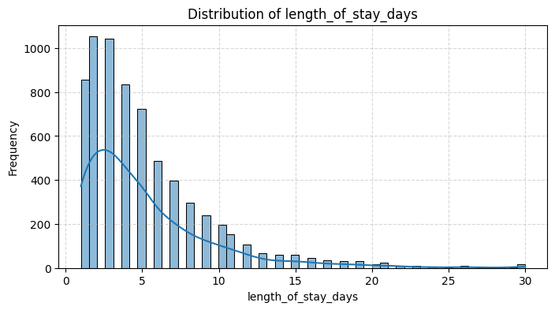

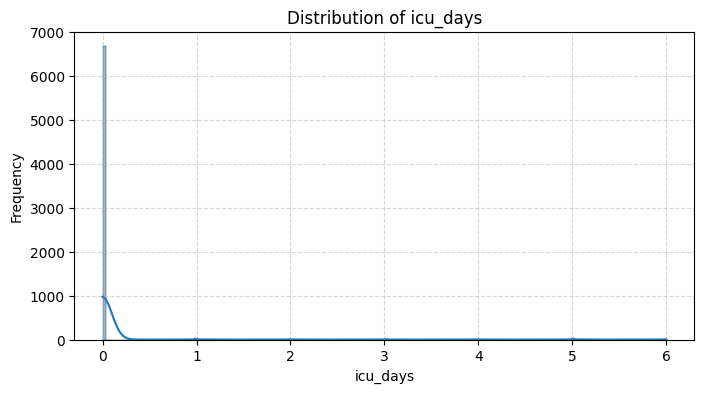

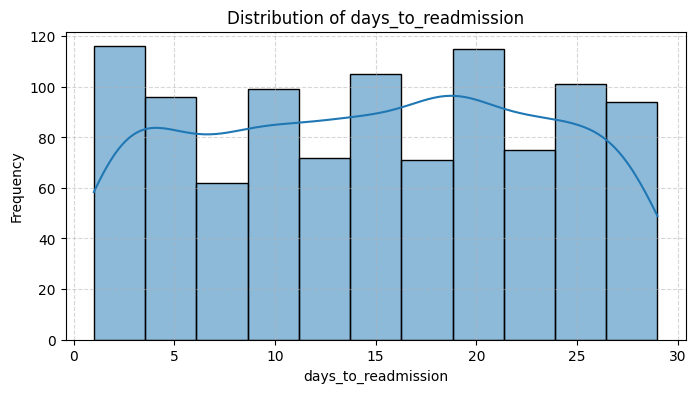

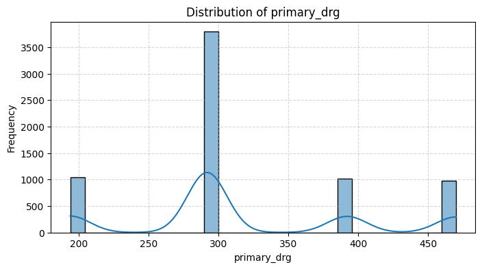

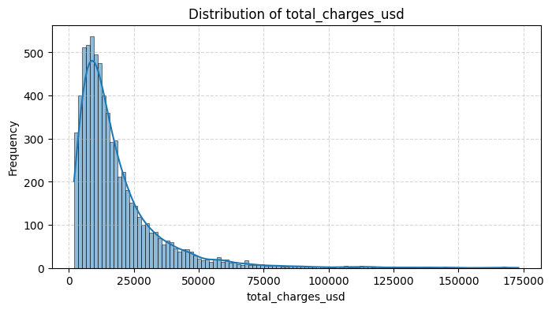

```python
# Histograms for each numerical outcome column to inspect shape and skew
for col in outcome_num_cols:
    plt.figure(figsize=(8, 4))
    sns.histplot(outcome_df[col].dropna(), kde=True)
    plt.title(f'Distribution of {col}')
    plt.xlabel(col)
    plt.ylabel('Frequency')
    plt.grid(True, linestyle='--', alpha=0.5)
    plt.show()
```

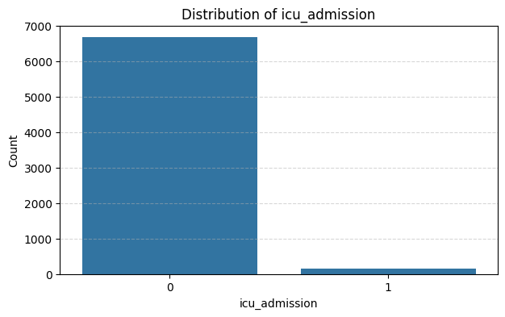

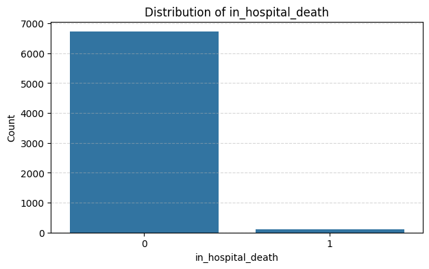

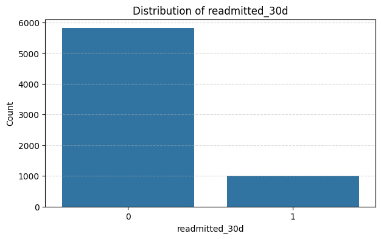

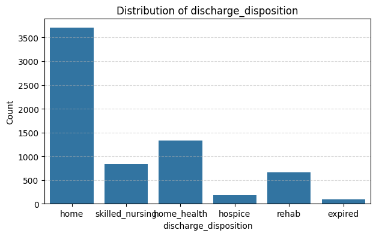

```python
# Count plots for binary and categorical outcome columns
binary_and_categorical_cols = ['icu_admission', 'in_hospital_death',
                               'readmitted_30d', 'discharge_disposition']
for col in binary_and_categorical_cols:
    plt.figure(figsize=(7, 4))
    sns.countplot(data=outcome_df, x=col)
    plt.title(f'Distribution of {col}')
    plt.xlabel(col)
    plt.ylabel('Count')
    plt.grid(axis='y', linestyle='--', alpha=0.5)
    plt.show()
```

```python
# Quick counts of binary == 1 cases for the outcome rates
binary_cols = ['icu_admission', 'in_hospital_death', 'readmitted_30d']
for col in binary_cols:
    print(f"Column '{col}': {outcome_df[col].sum()} patients with value 1")

# Verify the 'expired' discharge disposition count matches the in_hospital_death count
expired_n = (outcome_df['discharge_disposition'] == 'expired').sum()
print(f"Patients with discharge_disposition == 'expired': {expired_n}")
```

```
Column 'icu_admission': 152 patients with value 1
Column 'in_hospital_death': 100 patients with value 1
Column 'readmitted_30d': 1006 patients with value 1
Patients with discharge_disposition == 'expired': 100
```

The class imbalance is significant but not extreme: 152 ICU admissions, 100 in-hospital deaths, 1,006 readmissions out of 6,820 stays. We will not drop these as outliers because each represents a clinically important subgroup. The 100 in-hospital deaths exactly match the 100 'expired' discharge dispositions, a positive internal consistency check.

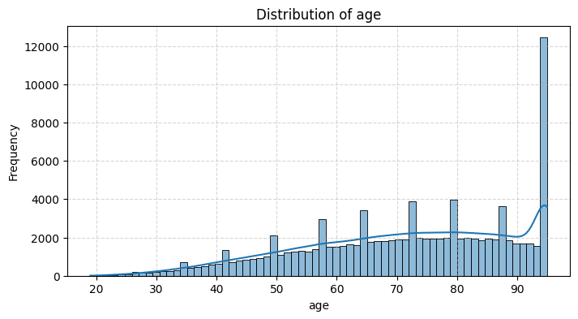

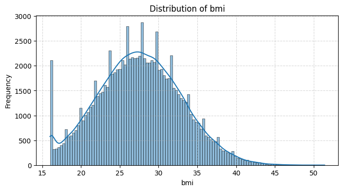

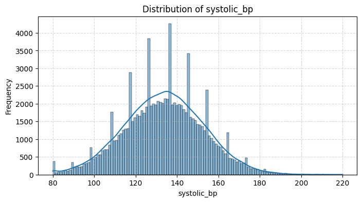

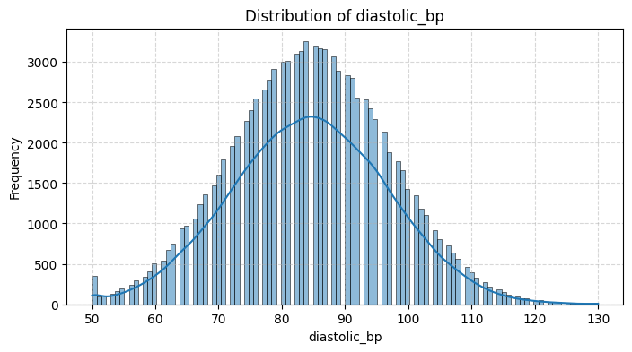

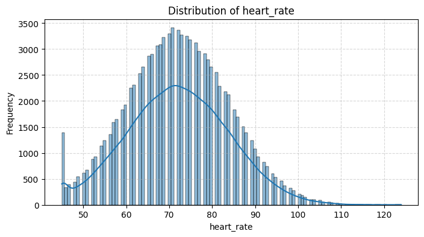

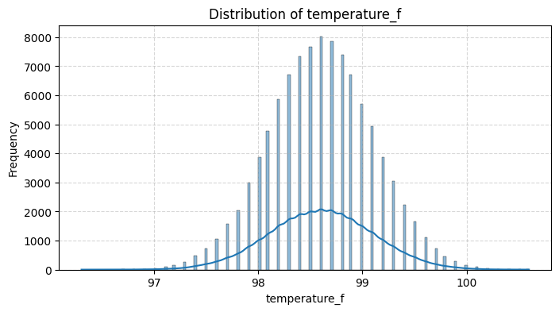

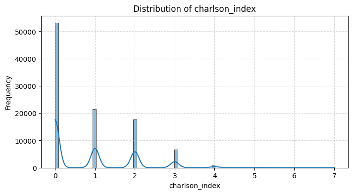

```python
# Histograms for numerical patient columns
for col in patient_num_cols:
    plt.figure(figsize=(8, 4))
    sns.histplot(patient_df[col].dropna(), kde=True)
    plt.title(f'Distribution of {col}')
    plt.xlabel(col)
    plt.ylabel('Frequency')
    plt.grid(True, linestyle='--', alpha=0.5)
    plt.show()
```

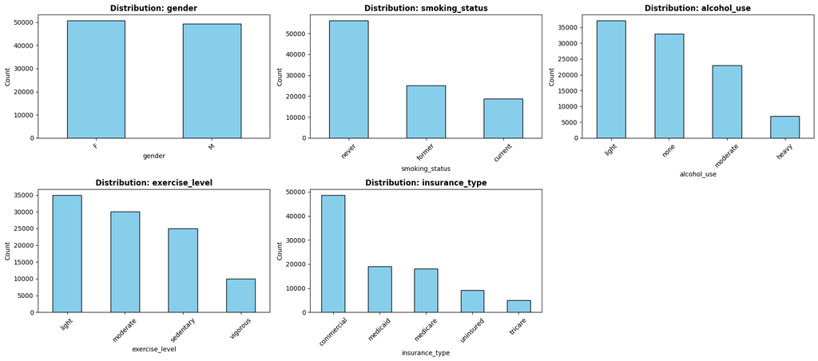

```python
# Bar charts for non-numeric columns in patient_df, excluding patient_id.
# select_dtypes(exclude='number') is dtype-agnostic across pandas versions
# (handles 'object', 'string', 'str', 'category').
obj_cols_to_plot = [
    col for col in patient_df.select_dtypes(exclude='number').columns
    if col != 'patient_id'
]

n_cols = 3
n_rows = math.ceil(len(obj_cols_to_plot) / n_cols)
fig, axes = plt.subplots(n_rows, n_cols, figsize=(18, n_rows * 4))
axes = axes.flatten()

for i, col in enumerate(obj_cols_to_plot):
    counts = patient_df[col].value_counts()
    counts.plot(kind='bar', ax=axes[i], color='skyblue', edgecolor='black')
    axes[i].set_title(f'Distribution: {col}', fontweight='bold')
    axes[i].set_ylabel('Count')
    axes[i].tick_params(axis='x', rotation=45)

for j in range(len(obj_cols_to_plot), len(axes)):
    fig.delaxes(axes[j])

plt.tight_layout()
plt.show()
```

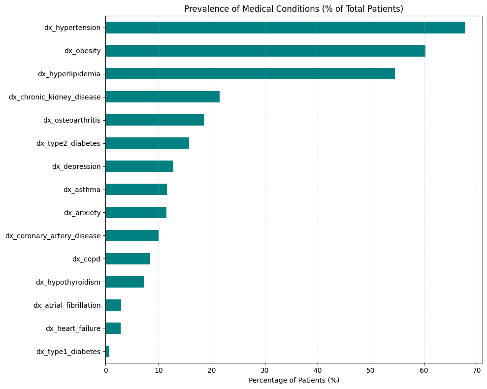

```python
# Prevalence of each medical condition as a percent of all patients
dx_cols = [col for col in patient_df.columns if col.startswith('dx_')]
prevalence = (patient_df[dx_cols].sum() / len(patient_df) * 100).sort_values(ascending=True)

plt.figure(figsize=(10, 8))
prevalence.plot(kind='barh', color='teal')
plt.title('Prevalence of Medical Conditions (% of Total Patients)')
plt.xlabel('Percentage of Patients (%)')
plt.grid(axis='x', linestyle='--', alpha=0.5)
plt.tight_layout()
plt.show()
```

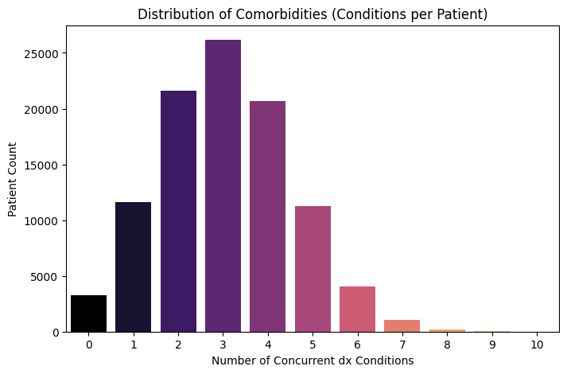

```python
# Distribution of the number of concurrent conditions per patient.
patient_df['total_dx_count'] = patient_df[dx_cols].sum(axis=1)
plt.figure(figsize=(8, 5))
sns.countplot(data=patient_df, x='total_dx_count', palette='magma',
              hue='total_dx_count', legend=False)
plt.title('Distribution of Comorbidities (Conditions per Patient)')
plt.xlabel('Number of Concurrent dx Conditions')
plt.ylabel('Patient Count')
plt.show()
```

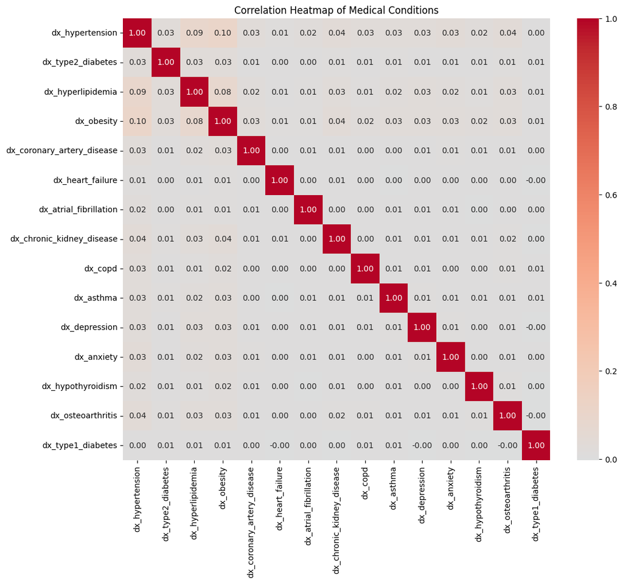

```python
# Correlation heatmap between the 15 binary dx columns. Off-diagonal blocks suggest clusters of conditions that may co-occur or travel together.
plt.figure(figsize=(12, 10))
sns.heatmap(patient_df[dx_cols].corr(), annot=True, fmt='.2f', cmap='coolwarm', center=0)
plt.title('Correlation Heatmap of Medical Conditions')
plt.show()
```

### 2.5 Data quality cross-checks

```python
# Duplicate patient IDs would break the later merge
print(f"Duplicate patient IDs: {patient_df['patient_id'].duplicated().sum()}")

# Duplicate full rows would inflate counts
print(f'Duplicate rows in patient_df: {patient_df.duplicated().sum()}')
print(f'Duplicate rows in outcome_df: {outcome_df.duplicated().sum()}')
```

```
Duplicate patient IDs: 0
Duplicate rows in patient_df: 0
Duplicate rows in outcome_df: 0
```

```python
# Logical date check: nobody should be discharged before admission
invalid_dates = outcome_df[outcome_df['discharge_date'] < outcome_df['admission_date']]
print(f'Rows with discharge before admission: {len(invalid_dates)}')
```

```
Rows with discharge before admission: 0
```

```python
# Physiological cross-check 1: systolic BP must be strictly greater than diastolic BP.
# Any row where systolic <= diastolic is medically impossible.
bp_issue_mask = patient_df['systolic_bp'] <= patient_df['diastolic_bp']
print(f'Rows with systolic_bp <= diastolic_bp: {bp_issue_mask.sum()}')

# Physiological cross-check 2: icu_days cannot exceed total length_of_stay_days
icu_issue_mask = outcome_df['icu_days'] > outcome_df['length_of_stay_days']
print(f'Rows with icu_days > length_of_stay_days: {icu_issue_mask.sum()}')
```

```
Rows with systolic_bp <= diastolic_bp: 1200
Rows with icu_days > length_of_stay_days: 51
```

### 2.6 Data quality decision

We found 1,200 BP-impossible rows (1.2% of patients) and 51 ICU-impossible rows (0.7% of outcomes). Our approach is to *flag* these rows rather than silently drop them at the source DataFrame, then exclude them from the primary analytical dataset when we merge in Section 4. Keeping a flagged copy lets us run a sensitivity analysis later if we want to confirm conclusions hold with or without the questionable rows.

```python
# Create a binary data_quality_flag column on each source DataFrame.
# 1 means the row failed at least one integrity check, 0 means it passed.
patient_df['data_quality_flag'] = bp_issue_mask.astype(int)
outcome_df['data_quality_flag'] = icu_issue_mask.astype(int)

print(f"Patients flagged for BP issue: {patient_df['data_quality_flag'].sum()}")
print(f"Outcomes flagged for ICU/LOS issue: {outcome_df['data_quality_flag'].sum()}")
```

```
Patients flagged for BP issue: 1200
Outcomes flagged for ICU/LOS issue: 51
```

## 3. Feature Engineering

We engineer features that turn raw EHR fields into clinically interpretable risk indicators and analytically useful inputs. For every transformation we record the method and the reason it was chosen here, because the encoding choice changes what downstream models can and cannot learn.

### 3.1 Encode categorical variables

| Feature | Method | Justification |
| --- | --- | --- |
| `gender` | Label encode (M=0, F=1) | Binary nominal; with only two levels, label encoding is equivalent to one-hot with drop_first |
| `smoking_status`, `alcohol_use`, `exercise_level` | Ordinal encode | These are ranked behaviors with a natural intensity ordering, so the order carries information that PCA can exploit |
| `insurance_type` | One-hot encode with `drop_first=True` | Nominal with no inherent order; dropping the first level avoids perfect multicollinearity (the dummy variable trap) which would distort variance-based methods like PCA |

```python
# Label encode gender. Either direction is arbitrary; we use M=0, F=1 to match the
# order in the unique value list.
patient_df['gender'] = patient_df['gender'].map({'M': 0, 'F': 1})
```

```python
# Ordinal encode the three lifestyle features.
# Order is fixed by clinical intensity (more = higher health risk for smoking/alcohol,
# more = lower risk for exercise but we still encode by intensity to keep direction
# consistent within each feature).
habit_maps = {
    'smoking_status':  {'never': 0, 'former': 1, 'current': 2},
    'alcohol_use':     {'none': 0, 'light': 1, 'moderate': 2, 'heavy': 3},
    'exercise_level':  {'sedentary': 0, 'light': 1, 'moderate': 2, 'vigorous': 3},
}
for col, mapping in habit_maps.items():
    patient_df[f'{col}_rank'] = patient_df[col].map(mapping)
```

```python
# One-hot encode insurance_type. drop_first=True omits one dummy column so the remaining
# dummies are not perfectly collinear. Without this PCA would inflate the variance
# attributable to insurance and the design matrix would be rank-deficient for any
# regression-based downstream method.
patient_df = pd.get_dummies(patient_df, columns=['insurance_type'], drop_first=True)
```

### 3.2 Risk and severity features

```python
# Comorbidity count: total number of chronic conditions per patient.
# Consolidates 15 sparse binary dx_ columns into one severity proxy that the model
# can weight as a single feature instead of fighting with 15 correlated indicators.
dx_cols = [col for col in patient_df.columns if col.startswith('dx_')]
patient_df['comorbidity_count'] = patient_df[dx_cols].sum(axis=1)
```

```python
# Pulse pressure: systolic minus diastolic blood pressure.
# A clinically meaningful derived vital sign. High pulse pressure is an independent cardiovascular risk indicator separate from mean arterial pressure.
patient_df['pulse_pressure'] = patient_df['systolic_bp'] - patient_df['diastolic_bp']
```

### 3.3 Clinical binning of continuous features

We bin three continuous features (age, blood pressure, BMI) into clinically meaningful categories. The bin edges are not arbitrary, they come from established medical thresholds. Binning loses some precision but lets us run stratified analyses and produces ordinal features that combine well with the ordinal lifestyle ranks.

```python
def assign_age_group(age):
    """Bin age into clinically meaningful groups. The 65 boundary aligns with US
    Medicare eligibility, which is a structural break in healthcare utilization."""
    if age < 40:
        return '<40'
    if age < 65:
        return '40-64'
    if age < 80:
        return '65-79'
    return '80+'


# Apply to all patients
patient_df['age_group'] = patient_df['age'].apply(assign_age_group)
patient_df['age_group'].value_counts()
```

```
age_group
80+      38089
40-64    29124
65-79    28409
<40       4378
Name: count, dtype: int64
```

```python
def assign_bp_category(sys_bp, dia_bp):
    """American Heart Association blood pressure categories. Crisis is medically urgent."""
    if sys_bp >= 180 or dia_bp >= 120:
        return 'Crisis'
    if sys_bp >= 140 or dia_bp >= 90:
        return 'Stage_2_HTN'
    if sys_bp >= 130 or dia_bp >= 80:
        return 'Stage_1_HTN'
    if sys_bp >= 120:
        return 'Elevated'
    return 'Normal'


# Apply row-wise: needs both systolic and diastolic so we use a lambda over the row.
patient_df['bp_category'] = patient_df.apply(
    lambda r: assign_bp_category(r['systolic_bp'], r['diastolic_bp']), axis=1)
patient_df['bp_category'].value_counts()
```

```
bp_category
Stage_2_HTN    56802
Stage_1_HTN    26162
Normal          9399
Elevated        6559
Crisis          1078
Name: count, dtype: int64
```

```python
def assign_bmi_category(bmi):
    """WHO BMI categories."""
    if bmi < 18.5:
        return 'Underweight'
    if bmi < 25:
        return 'Normal'
    if bmi < 30:
        return 'Overweight'
    if bmi < 40:
        return 'Obese'
    return 'Severely_Obese'


patient_df['bmi_category'] = patient_df['bmi'].apply(assign_bmi_category)
patient_df['bmi_category'].value_counts()
```

```
bmi_category
Overweight        35103
Obese             31531
Normal            27150
Underweight        5064
Severely_Obese     1152
Name: count, dtype: int64
```

### 3.4 Cost-related features

`daily_charge` is computed on the outcomes DataFrame. `high_cost_flag` depends on the distribution of total charges and is more interpretable when computed on the merged dataset, so we defer it to Section 4.

```python
# Daily charge: cost per day of stay. Normalizes a 1-day high-acuity stay
# against a 10-day routine stay so we can compare cost-per-day across stays of
# different durations.
outcome_df['daily_charge'] = outcome_df['total_charges_usd'] / outcome_df['length_of_stay_days']
outcome_df[['length_of_stay_days', 'total_charges_usd', 'daily_charge']].head()
```

|  | length_of_stay_days | total_charges_usd | daily_charge |
| --- | --- | --- | --- |
| 0 | 2 | 12069.89 | 6034.945000 |
| 1 | 1 | 14687.35 | 14687.350000 |
| 2 | 9 | 2065.34 | 229.482222 |
| 3 | 2 | 9888.26 | 4944.130000 |
| 4 | 2 | 15078.42 | 7539.210000 |

## 4. Data Merge

Here, we merge the datasets while using `patient_outcome` as the primary reference. A left join from `outcome_df` onto `patient_df` yields exactly the 6,820 patients who have a hospital stay, each enriched with their demographic, vital sign, lifestyle, and diagnosis context. This is the analytical dataset used for the remainder of the report.

```python
# Verify the join key:
# - patient_id should be unique in patient_df (each patient is one row).
# - patient_id may repeat in outcome_df only if a patient has multiple admissions.
print(f"Unique patient_id in patient_df: {patient_df['patient_id'].nunique()} / {len(patient_df)}")
print(f"Unique patient_id in outcome_df: {outcome_df['patient_id'].nunique()} / {len(outcome_df)}")
print(f"All outcome patient_ids exist in patient_df? {outcome_df['patient_id'].isin(patient_df['patient_id']).all()}")
```

```
Unique patient_id in patient_df: 100000 / 100000
Unique patient_id in outcome_df: 6820 / 6820
All outcome patient_ids exist in patient_df? True
```

```python
# Merge the data so we have one patient row per hospital stay enriched with patient details and context.
# Suffixes handle the data_quality_flag column that exists in both DataFrames.
merged_df_full = outcome_df.merge(
    patient_df,
    on='patient_id',
    how='left',
    suffixes=('_outcome', '_patient'),
)

# Combine the two integrity flags into a single column.
merged_df_full['data_quality_flag'] = (
    merged_df_full['data_quality_flag_outcome']
    | merged_df_full['data_quality_flag_patient']
).astype(int)
merged_df_full = merged_df_full.drop(
    columns=['data_quality_flag_outcome', 'data_quality_flag_patient'])

print(f'Merged shape (with flagged rows): {merged_df_full.shape}')
print(f"Flagged rows in merged data: {merged_df_full['data_quality_flag'].sum()}")
```

```
Merged shape (with flagged rows): (6820, 53)
Flagged rows in merged data: 95
```

```python
# Drop flagged rows for the primary analysis. Keep merged_df_full as a sensitivity backup, so we can compare against if needed.
merged_df = merged_df_full[merged_df_full['data_quality_flag'] == 0].copy()
print(f'Analytical merged shape (clean rows only): {merged_df.shape}')
```

```
Analytical merged shape (clean rows only): (6725, 53)
```

```python
# Create the deferred high_cost_flag feature.
# 1 if the stay is in the top quartile of total_charges_usd in the clean merged dataset.
# This gives us a clean binary target for A/B testing later.
cost_q75 = merged_df['total_charges_usd'].quantile(0.75)
merged_df['high_cost_flag'] = (merged_df['total_charges_usd'] >= cost_q75).astype(int)
print(f'75th percentile of total_charges_usd: ${cost_q75:,.2f}')
print(f"High-cost stays (top quartile): {merged_df['high_cost_flag'].sum()}")
```

```
75th percentile of total_charges_usd: $22,473.00
High-cost stays (top quartile): 1682
```

```python
# Confirm the merged DataFrame is well-formed before moving on
merged_df.head()
```

|  | patient_id | admission_date | discharge_date | length_of_stay_days | icu_admission | icu_days | in_hospital_death | discharge_disposition | readmitted_30d | days_to_readmission | primary_drg | total_charges_usd | daily_charge | age | gender | bmi | systolic_bp | diastolic_bp | heart_rate | temperature_f | smoking_status | alcohol_use | exercise_level | charlson_index | dx_hypertension | dx_type2_diabetes | dx_hyperlipidemia | dx_obesity | dx_coronary_artery_disease | … |
| --- | --- | --- | --- | --- | --- | --- | --- | --- | --- | --- | --- | --- | --- | --- | --- | --- | --- | --- | --- | --- | --- | --- | --- | --- | --- | --- | --- | --- | --- | --- |
| 0 | P0061265 | 2018-02-25 | 2018-02-27 | 2 | 0 | 0 | 0 | home | 0 | NaN | 470 | 12069.89 | 6034.945000 | 76 | 0 | 25.2 | 139 | 94 | 67 | 99.1 | current | heavy | moderate | 3 | 0 | 1 | 1 | 1 | 0 | … |
| 1 | P0098996 | 2023-06-07 | 2023-06-08 | 1 | 0 | 0 | 0 | skilled_nursing | 0 | NaN | 292 | 14687.35 | 14687.350000 | 88 | 1 | 18.4 | 157 | 109 | 63 | 99.3 | never | light | light | 0 | 0 | 0 | 1 | 0 | 0 | … |
| 2 | P0046588 | 2018-08-13 | 2018-08-22 | 9 | 0 | 0 | 0 | home | 0 | NaN | 470 | 2065.34 | 229.482222 | 88 | 0 | 31.7 | 147 | 92 | 77 | 99.3 | former | moderate | vigorous | 0 | 1 | 0 | 1 | 1 | 0 | … |
| 3 | P0058572 | 2022-06-11 | 2022-06-13 | 2 | 0 | 0 | 0 | home_health | 0 | NaN | 293 | 9888.26 | 4944.130000 | 95 | 1 | 27.6 | 167 | 68 | 55 | 98.8 | never | light | sedentary | 3 | 1 | 0 | 1 | 1 | 1 | … |
| 4 | P0080733 | 2021-05-23 | 2021-05-25 | 2 | 0 | 0 | 0 | skilled_nursing | 0 | NaN | 291 | 15078.42 | 7539.210000 | 78 | 1 | 36.9 | 132 | 88 | 61 | 98.4 | never | light | sedentary | 3 | 0 | 0 | 0 | 1 | 0 | … |

## 5. Principal Component Analysis (PCA)

**When PCA is not appropriate:**

- When original-feature interpretability is critical for the audience (PCs are weighted combinations).
- When the features are mostly binary or have non-linear relationships (PCA captures only linear variance).
- When the data is essentially uncorrelated. We verify this is not the case using KMO and Bartlett's test below.

### 5.1 Feature selection for PCA

We include continuous and ordinal features that describe patient state, health behavior, severity, and cost intensity. We exclude the 15 raw `dx_` binaries because their information is already captured by `comorbidity_count` and `charlson_index`. We also exclude the one-hot insurance dummies because nominal indicators inflate dimensionality without contributing to a continuous latent factor.

```python
# Feature list for PCA. Mix of continuous (age, bmi, BP, vitals) and ordinal (habit ranks).
pca_features = [
    'age', 'bmi', 'systolic_bp',
    'diastolic_bp',
    'pulse_pressure',
    'heart_rate', 'temperature_f',
    'charlson_index', 'comorbidity_count',
    'smoking_status_rank', 'alcohol_use_rank', 'exercise_level_rank',
    # 'length_of_stay_days', # Excluded based on very low KMO < 0.3
    'total_charges_usd', 'daily_charge',
]

# Drop rows with any nulls in the selected features. Should be zero given our cleaning.
pca_input = merged_df[pca_features].dropna().copy()
print(f'PCA input shape: {pca_input.shape}')
```

```
PCA input shape: (6725, 14)
```

### 5.2 Standardize

PCA decomposes the covariance matrix. Without scaling, features with large numeric range (`total_charges_usd` ranges over tens of thousands) would dominate features with small range (`bmi` ranges over tens), and the first PC would essentially be the cost axis. `StandardScaler` rescales each feature to mean 0 and standard deviation 1 so every feature gets a fair chance to load on each PC.

```python
# Fit and apply the z-score scaler. The output is a numpy array of standardized values.
scaler = StandardScaler()
pca_scaled = scaler.fit_transform(pca_input)

# Wrap back in a DataFrame so column names survive for downstream interpretation.
pca_scaled_df = pd.DataFrame(pca_scaled, columns=pca_features, index=pca_input.index)
pca_scaled_df.describe().round(2)   # means ~0, std ~1 confirm scaling worked
```

|  | age | bmi | systolic_bp | diastolic_bp | pulse_pressure | heart_rate | temperature_f | charlson_index | comorbidity_count | smoking_status_rank | alcohol_use_rank | exercise_level_rank | total_charges_usd | daily_charge |
| --- | --- | --- | --- | --- | --- | --- | --- | --- | --- | --- | --- | --- | --- | --- |
| count | 6725.00 | 6725.00 | 6725.00 | 6725.00 | 6725.00 | 6725.00 | 6725.00 | 6725.00 | 6725.00 | 6725.00 | 6725.00 | 6725.00 | 6725.00 | 6725.00 |
| mean | -0.00 | 0.00 | -0.00 | 0.00 | 0.00 | -0.00 | 0.00 | -0.00 | 0.00 | 0.00 | -0.00 | 0.00 | -0.00 | -0.00 |
| std | 1.00 | 1.00 | 1.00 | 1.00 | 1.00 | 1.00 | 1.00 | 1.00 | 1.00 | 1.00 | 1.00 | 1.00 | 1.00 | 1.00 |
| min | -3.70 | -2.13 | -3.09 | -2.88 | -2.39 | -2.29 | -3.43 | -1.16 | -2.43 | -0.81 | -1.13 | -1.31 | -0.96 | -0.69 |
| 25% | -0.44 | -0.69 | -0.70 | -0.70 | -0.67 | -0.68 | -0.60 | -1.16 | -0.41 | -0.81 | -1.13 | -1.31 | -0.61 | -0.52 |
| 50% | 0.16 | 0.01 | 0.01 | 0.03 | -0.01 | 0.00 | 0.00 | -0.30 | 0.26 | -0.81 | -0.04 | -0.25 | -0.30 | -0.31 |
| 75% | 0.82 | 0.69 | 0.67 | 0.68 | 0.66 | 0.68 | 0.61 | 0.57 | 0.94 | 0.48 | 1.05 | 0.81 | 0.24 | 0.11 |
| max | 1.15 | 3.68 | 3.72 | 3.43 | 3.61 | 3.82 | 4.05 | 3.15 | 4.30 | 1.76 | 2.14 | 1.87 | 9.14 | 18.76 |

### 5.3 Multicollinearity check via Variance Inflation Factor (VIF)

VIF measures how much the variance of each feature is inflated by its correlation with the other features in the matrix. A VIF of 1 means the feature is uncorrelated with the rest; VIF between 1 and 5 is moderate; greater than 5 is high; greater than 10 is severe. High VIF *strengthens* the case for PCA because PCA is designed to consolidate redundant correlated features.

```python
def compute_vif(X, feature_names):
    """Return a tidy DataFrame of variance inflation factors, sorted descending.

    Parameters
    ----------
    X : array-like of shape (n_samples, n_features)
        Already standardized feature matrix.
    feature_names : list of str
        Names matching the columns of X.
    """
    rows = []
    X = np.asarray(X)
    for i, name in enumerate(feature_names):
        rows.append({'feature': name, 'VIF': variance_inflation_factor(X, i)})
    return pd.DataFrame(rows).sort_values('VIF', ascending=False).reset_index(drop=True)


vif_df = compute_vif(pca_scaled, pca_features)
vif_df
```

|  | feature | VIF |
| --- | --- | --- |
| 0 | systolic_bp | inf |
| 1 | diastolic_bp | inf |
| 2 | pulse_pressure | inf |
| 3 | comorbidity_count | 1.686686 |
| 4 | total_charges_usd | 1.683711 |
| 5 | daily_charge | 1.683144 |
| 6 | charlson_index | 1.439630 |
| 7 | age | 1.392954 |
| 8 | exercise_level_rank | 1.002387 |
| 9 | temperature_f | 1.002131 |
| 10 | heart_rate | 1.002075 |
| 11 | bmi | 1.001941 |
| 12 | alcohol_use_rank | 1.001102 |
| 13 | smoking_status_rank | 1.000730 |

**Interpretation:** The inf values for systolic_bp, diastolic_bp, and pulse_pressure indicate perfect multicollinearity, which is expected since pulse pressure is a direct mathematical derivative of the other two. While this level of redundancy would typically require dropping features in a standard regression, we will retain them here as Principal Component Analysis (PCA) is specifically designed to consolidate such highly correlated variables into meaningful latent dimensions. All other features show low VIF scores (generally < 2.5), suggesting they mostly contribute independent information to the model.

### 5.4 Pre-PCA suitability tests: KMO and Bartlett's sphericity

Before running PCA, we verify the data is actually suitable for dimensionality reduction. If features are essentially uncorrelated, PCA has nothing to compress.

**Bartlett's test of sphericity:**

- H0: the correlation matrix is the identity (all off-diagonal correlations are 0).
- H1: at least some features are correlated.
- We need to *reject* H0 (small p-value, typically < 0.05) for PCA to be appropriate.

**Kaiser-Meyer-Olkin (KMO):** an overall measure of shared structure between 0 and 1.

Interpretation usually bands:

- 0.90 to 1.00: Marvelous (Excellent)
- 0.80 to 0.89: Meritorious (Very Good)
- 0.70 to 0.79: Middling (Good/Acceptable)
- 0.60 to 0.69: Mediocre (Barely Acceptable)
- 0.50 to 0.59: Miserable (Poor)
- Below 0.50: unacceptable, drop low-KMO features and re-check

```python
def check_pca_suitability(X_scaled, feature_names):
    """Run Bartlett's sphericity test and KMO on a scaled feature matrix.

    Returns a dict with the chi-square, p-value, per-variable KMO Series,
    and the overall KMO score.
    """
    chi_sq, p_value = calculate_bartlett_sphericity(X_scaled)
    kmo_per_var, kmo_overall = calculate_kmo(X_scaled)
    return {
        'bartlett_chi_square': chi_sq,
        'bartlett_p_value': p_value,
        'kmo_per_variable': pd.Series(kmo_per_var, index=feature_names).sort_values(),
        'kmo_overall': kmo_overall,
    }


suitability = check_pca_suitability(pca_scaled, pca_features)
print(f"Bartlett chi-square: {suitability['bartlett_chi_square']:.2f}")
print(f"Bartlett p-value:    {suitability['bartlett_p_value']:.4g}")
print(f"KMO overall:         {suitability['kmo_overall']:.3f}")
print('KMO per variable (ascending):')
print(suitability['kmo_per_variable'].round(3))
```

```
Bartlett chi-square: nan
Bartlett p-value:    nan
KMO overall:         0.511
KMO per variable (ascending):
diastolic_bp           0.386
temperature_f          0.421
bmi                    0.424
alcohol_use_rank       0.426
age                    0.464
heart_rate             0.465
charlson_index         0.472
exercise_level_rank    0.486
smoking_status_rank    0.493
systolic_bp            0.494
total_charges_usd      0.500
daily_charge           0.500
comorbidity_count      0.505
pulse_pressure         0.670
dtype: float64
```

**Interpreting the KMO and Bartlett results.**

We proceed with PCA because the test is not unacceptable (above 0.50), but we treat the components as a diagnostic axis rather than a strong basis for downstream modeling, and we will pivot to clinically-defined patient segments in Section 6.5 for the A/B and simulation work.

### 5.5 Fit PCA and select the number of components

```python
def run_pca(X_scaled, n_components=None, seed=RANDOM_SEED):
    """Fit PCA on a standardized matrix and return the fitted estimator plus scores.

    n_components=None fits a full PCA so we can inspect eigenvalues and pick K downstream.
    """
    pca = PCA(n_components=n_components, random_state=seed)
    scores = pca.fit_transform(X_scaled)
    return pca, scores


# Fit full PCA first so we can inspect every eigenvalue and variance explained.
pca_full, scores_full = run_pca(pca_scaled, n_components=None)

# explained_variance_ are eigenvalues; explained_variance_ratio_ is share of total variance.
explained_var = pd.DataFrame({
    'PC': [f'PC{i+1}' for i in range(len(pca_full.explained_variance_))],
    'eigenvalue': pca_full.explained_variance_,
    'variance_ratio': pca_full.explained_variance_ratio_,
    'cumulative_variance': np.cumsum(pca_full.explained_variance_ratio_),
})
explained_var.round(4)
```

|  | PC | eigenvalue | variance_ratio | cumulative_variance |
| --- | --- | --- | --- | --- |
| 0 | PC1 | 2.0587 | 0.1470 | 0.1470 |
| 1 | PC2 | 1.6952 | 0.1211 | 0.2681 |
| 2 | PC3 | 1.6275 | 0.1162 | 0.3843 |
| 3 | PC4 | 1.2201 | 0.0871 | 0.4715 |
| 4 | PC5 | 1.0357 | 0.0740 | 0.5454 |
| 5 | PC6 | 1.0246 | 0.0732 | 0.6186 |
| 6 | PC7 | 1.0046 | 0.0717 | 0.6904 |
| 7 | PC8 | 0.9935 | 0.0710 | 0.7613 |
| 8 | PC9 | 0.9745 | 0.0696 | 0.8309 |
| 9 | PC10 | 0.9615 | 0.0687 | 0.8996 |
| 10 | PC11 | 0.6768 | 0.0483 | 0.9479 |
| 11 | PC12 | 0.3747 | 0.0268 | 0.9747 |
| 12 | PC13 | 0.3546 | 0.0253 | 1.0000 |
| 13 | PC14 | 0.0000 | 0.0000 | 1.0000 |

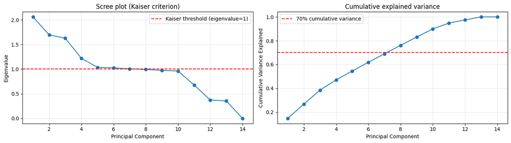

```python
# Scree plot: each PC's eigenvalue. The elbow marks diminishing returns.
fig, axes = plt.subplots(1, 2, figsize=(14, 4))

axes[0].plot(range(1, len(pca_full.explained_variance_) + 1),
             pca_full.explained_variance_, marker='o')
axes[0].axhline(1.0, color='red', linestyle='--', label='Kaiser threshold (eigenvalue=1)')
axes[0].set_xlabel('Principal Component')
axes[0].set_ylabel('Eigenvalue')
axes[0].set_title('Scree plot (Kaiser criterion)')
axes[0].legend()
axes[0].grid(alpha=0.3)

# Cumulative variance plot with 70% reference line.
axes[1].plot(range(1, len(pca_full.explained_variance_) + 1),
             np.cumsum(pca_full.explained_variance_ratio_), marker='o')
axes[1].axhline(0.70, color='red', linestyle='--', label='70% cumulative variance')
axes[1].set_xlabel('Principal Component')
axes[1].set_ylabel('Cumulative Variance Explained')
axes[1].set_title('Cumulative explained variance')
axes[1].legend()
axes[1].grid(alpha=0.3)

plt.tight_layout()
plt.show()
```

### 5.6 Choosing the number of components

**Interpreting the three component-selection criteria for this dataset.**

1. **Kaiser criterion (eigenvalue > 1):** retains 7 components. This is unusually many; a clean PCA application usually has 3 to 5 eigenvalues above 1.
2. **Scree elbow:** the inflection point sits around PC4. After PC4 the eigenvalue curve flattens, with PCs 5 through 7 each barely clearing the eigenvalue = 1 threshold.
3. **Cumulative variance:** 7 components are needed to reach 69.04%, just shy of the 70% target. PC1 through PC4 together capture only ~47%.

**What this means:** the criteria disagree, which itself is the finding. Kaiser is permissive here because so many features are essentially independent that each contributes its own eigenvalue near 1. The scree elbow at PC4 with under 50% variance is a more honest summary. We retain Kaiser's 7 components for completeness in Section 5.7's loadings interpretation, but we acknowledge that PCs 5 to 7 carry very limited information and the dataset does not have a strong low-dimensional structure for clustering to exploit.

```python
# Set N_COMPONENTS based on the diagnostics above. Adjust after inspecting the plots.
# Pick the smallest n such that the three criteria converge.
N_COMPONENTS = int((explained_var['eigenvalue'] >= 1).sum())
print(f'Components retained by Kaiser rule: {N_COMPONENTS}')
print(f"Cumulative variance retained: {explained_var.iloc[N_COMPONENTS-1]['cumulative_variance']:.2%}")
```

```
Components retained by Kaiser rule: 7
Cumulative variance retained: 69.04%
```

```python
# Refit PCA with the chosen number of components for interpretation and downstream clustering.
pca_final, pc_scores = run_pca(pca_scaled, n_components=N_COMPONENTS)

# Wrap the PC scores in a DataFrame indexed to the merged_df rows we used.
pc_score_cols = [f'PC{i+1}' for i in range(N_COMPONENTS)]
pc_scores_df = pd.DataFrame(pc_scores, columns=pc_score_cols, index=pca_input.index)
pc_scores_df.head()
```

|  | PC1 | PC2 | PC3 | PC4 | PC5 | PC6 | PC7 |
| --- | --- | --- | --- | --- | --- | --- | --- |
| 0 | 0.242813 | 0.985932 | -0.774099 | -0.493738 | 0.988298 | 2.315353 | 1.766454 |
| 1 | 0.070827 | 0.287782 | 0.687513 | 2.846977 | -0.947403 | 1.147536 | 0.121806 |
| 2 | 0.643265 | -0.048769 | -1.241710 | 1.129072 | 1.205741 | 0.558217 | 1.739440 |
| 3 | 3.696344 | -0.560046 | -0.544114 | -1.180642 | -0.341111 | 0.530031 | -1.358915 |
| 4 | -0.185772 | 0.581121 | -0.307810 | -0.654756 | 0.486863 | -0.756702 | -1.421541 |

### 5.7 Interpret the principal components

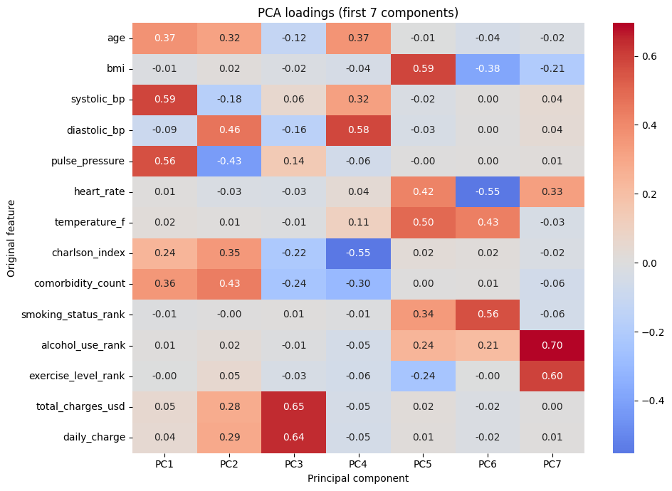

```
PC1 top loadings:
systolic_bp          0.588
pulse_pressure       0.563
age                  0.372
comorbidity_count    0.358
Name: PC1, dtype: float64

PC2 top loadings:
diastolic_bp         0.462
comorbidity_count    0.434
pulse_pressure      -0.425
charlson_index       0.350
Name: PC2, dtype: float64

PC3 top loadings:
total_charges_usd    0.646
daily_charge         0.642
comorbidity_count   -0.242
charlson_index      -0.218
Name: PC3, dtype: float64

PC4 top loadings:
diastolic_bp      0.583
charlson_index   -0.548
age               0.368
systolic_bp       0.322
Name: PC4, dtype: float64

PC5 top loadings:
bmi                    0.588
temperature_f          0.496
heart_rate             0.418
smoking_status_rank    0.341
Name: PC5, dtype: float64

PC6 top loadings:
smoking_status_rank    0.562
heart_rate            -0.552
temperature_f          0.429
bmi                   -0.383
Name: PC6, dtype: float64

PC7 top loadings:
alcohol_use_rank       0.696
exercise_level_rank    0.596
heart_rate             0.326
bmi                   -0.206
Name: PC7, dtype: float64
```

```python
# Loadings = correlations between original features and each PC. They tell us which
# original variables drive each PC, which is how we name the components.
loadings = pd.DataFrame(
    pca_final.components_.T,
    columns=pc_score_cols,
    index=pca_features,
)

plt.figure(figsize=(10, 7))
sns.heatmap(loadings, annot=True, fmt='.2f', cmap='coolwarm', center=0)
plt.title(f'PCA loadings (first {N_COMPONENTS} components)')
plt.ylabel('Original feature')
plt.xlabel('Principal component')
plt.tight_layout()
plt.show()

# Print the top three features (by absolute loading) for each component
for pc in pc_score_cols:
    top = loadings[pc].abs().sort_values(ascending=False).head(4)
    print(f'{pc} top loadings:')
    print(loadings.loc[top.index, pc].round(3))
    print()
```

**Attempting PC Interpretation:**

- **PC1: Vascular pressure and aging.** Loads strongest on systolic_bp (0.59), pulse_pressure (0.56), age (0.37), and comorbidity_count (0.36). This captures the classic vascular aging signal: older patients with elevated systolic pressure and a widened systolic-diastolic gap, accompanied by greater chronic disease burden.
- **PC2: Diastolic-dominant chronic burden.** Loads on diastolic_bp (0.46), comorbidity_count (0.43), charlson_index (0.35), and age (0.32), with a strong negative loading on pulse_pressure (-0.43). Patients high on PC2 show elevated diastolic pressure with a narrow pressure gap plus high comorbidity. This isolates a different cardiovascular phenotype from PC1: earlier-stage hypertension with chronic disease, rather than later-stage vascular stiffening.
- **PC3: Cost and utilization.** Loads almost entirely on total_charges_usd (0.65) and daily_charge (0.64), with mild negative loadings on comorbidity_count (-0.24) and charlson_index (-0.22). This is a near-pure cost axis. The slight negative comorbidity loading is worth noting: it suggests the highest-cost stays in this dataset tend to be acute, single-episode admissions rather than chronic-disease driven stays.
- **PC4: Isolated hypertension without comorbidity.** Loads on diastolic_bp (0.58), age (0.37), and systolic_bp (0.32) on the positive side, and strongly negatively on charlson_index (-0.55) and comorbidity_count (-0.30). Patients high on PC4 are older with elevated blood pressure but few documented comorbidities, an "isolated hypertensive" or possibly under-diagnosed phenotype.
- **PC5: Metabolic and inflammatory state.** Loads on bmi (0.59), temperature_f (0.50), heart_rate (0.42), and smoking_status_rank (0.34), with a small negative on exercise_level_rank (-0.24). A metabolic-inflammatory axis: higher BMI, slightly elevated temperature and resting heart rate, more smoking, less exercise.
- **PC6: Smoking phenotype with bradycardia (slow heart rate).** Loads on smoking_status_rank (0.56) and temperature_f (0.43) positive, and on heart_rate (-0.55) and bmi (-0.38) negative. The combination of heavy smoking with a low resting heart rate is somewhat unusual; in real-world data this often reflects long-term smokers on rate-lowering medications such as beta-blockers, but in a synthetic dataset it may simply be a residual axis after PC5 absorbs most of the metabolic signal.
- **PC7: Active drinker lifestyle.** Loads on alcohol_use_rank (0.70) and exercise_level_rank (0.60), with a smaller positive on heart_rate (0.33) and a slight negative on bmi (-0.21). Captures a lifestyle pattern where high alcohol consumption co-occurs with high physical activity, suggestive of a younger or more socially active subset rather than a clinical risk axis.

### 5.8 Tradeoffs to consider

- PCs are weighted combinations of original features, so we lose direct interpretability. We mitigate by naming each PC using its dominant loadings.
- PCA only captures linear structure. For non-linear patterns t-SNE or UMAP (visualization) or kernel PCA (analysis) are alternatives.
- PCA is sensitive to outliers because variance is a squared metric. Mitigation: remove extreme outliers, or use robust PCA.
- PCA assumes features are at least roughly continuous. Forcing many binary features through PCA tends to produce uninformative components.

## 6. Clustering

**Why clustering, when to use it:** unsupervised segmentation when we want to discover natural groupings without a labeled target. Useful in healthcare for cohort discovery, risk stratification, and intervention targeting. The principal components from Section 5 are an ideal input because they are decorrelated, standardized, and low-dimensional.

**Why K-Means specifically:** fast on thousands of rows, easy to communicate to a non-technical stakeholder, and works well when clusters are roughly spherical in the reduced PC space.

### 6.1 Choose the number of clusters

```python
def choose_k(X, k_range=range(2, 11), seed=RANDOM_SEED):
    """Run K-Means for each k in k_range, returning inertia and silhouette score.

    Inertia (within-cluster sum of squares) drives the elbow plot.
    Silhouette score in [-1, 1] measures how well-separated the clusters are.
    """
    rows = []
    for k in k_range:
        km = KMeans(n_clusters=k, n_init=10, random_state=seed)
        labels = km.fit_predict(X)
        rows.append({
            'k': k,
            'inertia': km.inertia_,
            'silhouette': silhouette_score(X, labels),
        })
    return pd.DataFrame(rows)


k_diag = choose_k(pc_scores, k_range=range(2, 11))
k_diag
```

|  | k | inertia | silhouette |
| --- | --- | --- | --- |
| 0 | 2 | 56080.922562 | 0.134296 |
| 1 | 3 | 50382.226657 | 0.143170 |
| 2 | 4 | 45436.951680 | 0.132656 |
| 3 | 5 | 42361.793460 | 0.123875 |
| 4 | 6 | 40612.775267 | 0.107795 |
| 5 | 7 | 39066.252378 | 0.106539 |
| 6 | 8 | 37757.012231 | 0.107908 |
| 7 | 9 | 36579.475879 | 0.102749 |
| 8 | 10 | 35364.912151 | 0.105891 |

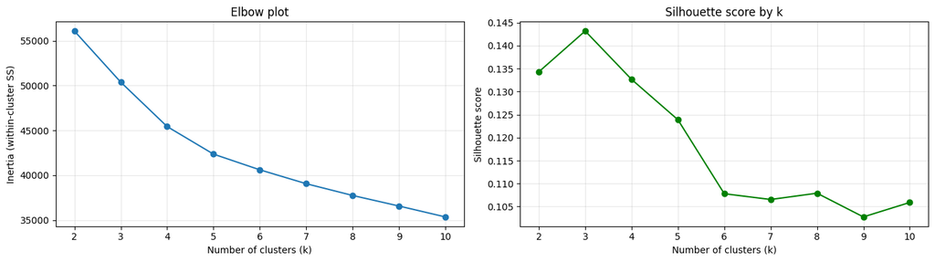

```python
# Plot the elbow (inertia) and the silhouette score side by side
fig, axes = plt.subplots(1, 2, figsize=(14, 4))

axes[0].plot(k_diag['k'], k_diag['inertia'], marker='o')
axes[0].set_xlabel('Number of clusters (k)')
axes[0].set_ylabel('Inertia (within-cluster SS)')
axes[0].set_title('Elbow plot')
axes[0].grid(alpha=0.3)

axes[1].plot(k_diag['k'], k_diag['silhouette'], marker='o', color='green')
axes[1].set_xlabel('Number of clusters (k)')
axes[1].set_ylabel('Silhouette score')
axes[1].set_title('Silhouette score by k')
axes[1].grid(alpha=0.3)

plt.tight_layout()
plt.show()
```

**Interpreting the elbow and silhouette together.**

The elbow plot has no clear inflection: inertia declines gently and continuously from k = 2 to k = 10, which is the visual signature of a dataset without natural geometric gaps between clusters.

The silhouette score is more diagnostic. It peaks at k = 3 with a value of 0.143, then declines as k grows. Using standard interpretation bands (0.71+ strong, 0.51 to 0.70 reasonable, 0.26 to 0.50 weak, 0.25 or below problematic), a peak of 0.143 falls clearly inside the **problematic** band. This means even the best K-Means partition we can build here has very weak cluster separation: most points are roughly equidistant from their own centroid and the nearest neighboring centroid.

We proceed with k = 3 to demonstrate the technique and produce the per-sample silhouette plot below, but we treat the resulting cluster labels as exploratory rather than as a basis for downstream inference. Section 6.5 introduces a clinically-defined segmentation that replaces the K-Means cluster labels for the A/B tests and simulations.

```python
# Pick K based on the diagnostics above. Adjust if the elbow points elsewhere.
K_FINAL = int(k_diag.loc[k_diag['silhouette'].idxmax(), 'k'])
print(f'Selected K based on max silhouette: {K_FINAL}')
```

```
Selected K based on max silhouette: 3
```

### 6.2 Fit final K-Means and produce a per-sample silhouette plot

```python
def run_kmeans(X, k, seed=RANDOM_SEED):
    """Fit KMeans with multiple inits and return both the fitted model and the labels."""
    km = KMeans(n_clusters=k, n_init=10, random_state=seed)
    labels = km.fit_predict(X)
    return km, labels


kmeans_model, cluster_labels = run_kmeans(pc_scores, K_FINAL)

# Attach the cluster label to the merged DataFrame for profiling and A/B testing.
merged_df = merged_df.loc[pc_scores_df.index].copy()
merged_df['cluster'] = cluster_labels
merged_df['cluster'].value_counts().sort_index()
```

```
cluster
0    2994
1    3223
2     508
Name: count, dtype: int64
```

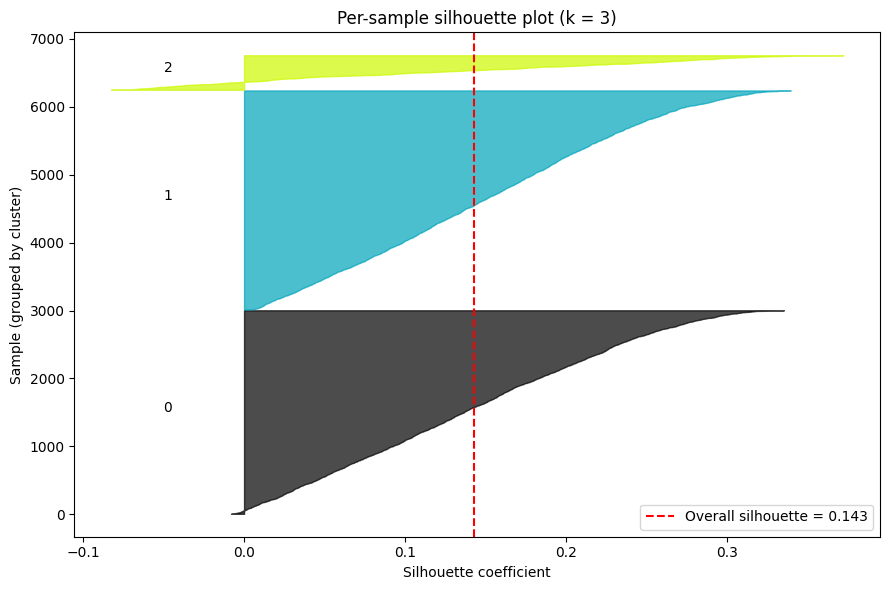

```python
def plot_silhouette(X, labels, k):
    """Per-sample silhouette plot colored by cluster. Reveals whether *every* cluster
    is well-formed, which the scalar silhouette_score cannot show."""
    sample_sils = silhouette_samples(X, labels)
    overall = silhouette_score(X, labels)

    fig, ax = plt.subplots(figsize=(9, 6))
    y_lower = 10
    for i in range(k):
        cluster_sils = np.sort(sample_sils[labels == i])
        size_i = cluster_sils.shape[0]
        y_upper = y_lower + size_i
        color = cm.nipy_spectral(float(i) / k)
        ax.fill_betweenx(np.arange(y_lower, y_upper),
                         0, cluster_sils,
                         facecolor=color, edgecolor=color, alpha=0.7)
        ax.text(-0.05, y_lower + 0.5 * size_i, str(i))
        y_lower = y_upper + 10

    ax.axvline(overall, color='red', linestyle='--',
               label=f'Overall silhouette = {overall:.3f}')
    ax.set_xlabel('Silhouette coefficient')
    ax.set_ylabel('Sample (grouped by cluster)')
    ax.set_title(f'Per-sample silhouette plot (k = {k})')
    ax.legend()
    plt.tight_layout()
    plt.show()


plot_silhouette(pc_scores, cluster_labels, K_FINAL)
```

### 6.3 Profile each cluster

For each cluster we compute average values of the outcome metrics and patient characteristics that matter most for healthcare decisions. The profile is what lets us *name* each cluster (e.g., high-acuity seniors vs healthy young adults).

```python
# Numerical profile of each cluster. We pull the metrics that matter clinically and
# financially: severity, vitals, behaviors, costs, and outcomes.
profile_cols = [
    'age', 'comorbidity_count', 'charlson_index',
    'bmi', 'systolic_bp', 'diastolic_bp', 'heart_rate', 'pulse_pressure',
    'smoking_status_rank', 'alcohol_use_rank', 'exercise_level_rank',
    'length_of_stay_days', 'total_charges_usd', 'daily_charge',
    'icu_admission', 'readmitted_30d', 'in_hospital_death', 'high_cost_flag',
]
cluster_profile = merged_df.groupby('cluster')[profile_cols].mean().round(2)
cluster_profile
```

| cluster | age | comorbidity_count | charlson_index | bmi | systolic_bp | diastolic_bp | heart_rate | pulse_pressure | smoking_status_rank | alcohol_use_rank | exercise_level_rank | length_of_stay_days | total_charges_usd | daily_charge | icu_admission | readmitted_30d | in_hospital_death | high_cost_flag |
| --- | --- | --- | --- | --- | --- | --- | --- | --- | --- | --- | --- | --- | --- | --- | --- | --- | --- | --- |
| 0 | 70.77 | 2.93 | 0.99 | 27.67 | 123.84 | 86.95 | 71.99 | 36.89 | 0.63 | 1.03 | 1.25 | 5.29 | 15025.14 | 4606.75 | 0.01 | 0.12 | 0.01 | 0.19 |
| 1 | 83.82 | 4.23 | 1.67 | 27.46 | 148.67 | 84.30 | 72.11 | 64.37 | 0.62 | 1.03 | 1.23 | 5.54 | 14985.65 | 4459.68 | 0.02 | 0.17 | 0.02 | 0.19 |
| 2 | 78.79 | 3.64 | 1.37 | 27.59 | 137.74 | 86.24 | 70.92 | 51.50 | 0.68 | 1.10 | 1.22 | 3.27 | 58953.46 | 26996.41 | 0.02 | 0.16 | 0.02 | 1.00 |

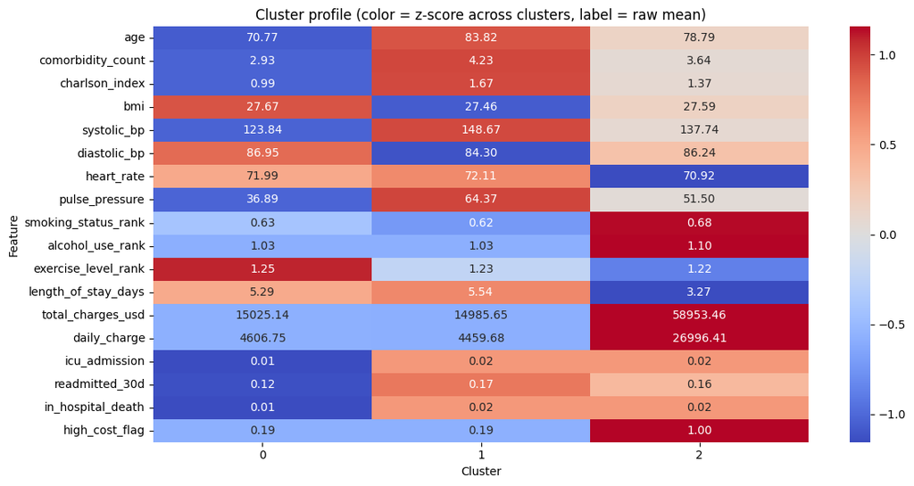

```python
# Visualize the profile as a heatmap. Standardize across clusters first so high and
# low values are visible on the same color scale.
profile_z = (cluster_profile - cluster_profile.mean()) / cluster_profile.std()

plt.figure(figsize=(12, 6))
sns.heatmap(profile_z.T, annot=cluster_profile.T, fmt='.2f',
            cmap='coolwarm', center=0)
plt.title('Cluster profile (color = z-score across clusters, label = raw mean)')
plt.xlabel('Cluster')
plt.ylabel('Feature')
plt.tight_layout()
plt.show()
```

**Interpreting the K-Means cluster profile.**

The profile table and heatmap reveal the structural problem behind the 0.143 silhouette. The three clusters K-Means produced are:

- **Cluster 0:** youngest (mean age 70.8), lowest comorbidity (2.93), borderline Stage 1 hypertension by the AHA classifier we built in Section 3.3 (124/87, driven by the diastolic), moderate cost (~$15,000), 19% high-cost flag.
- **Cluster 1:** oldest (mean age 83.8), highest comorbidity (4.23), Stage 2 systolic hypertension by the AHA classifier (149/...), similar moderate cost (~$15,000), 19% high-cost flag.
- **Cluster 2:** middle on demographics (age 78.8, comorbidity 3.64) but **dramatically higher cost** (mean $58,953, mean daily charge $26,996, 100% high-cost flag).

In other words, Clusters 0 and 1 differ only on age and comorbidity but are nearly identical on cost and outcomes, and Cluster 2 is essentially the high-cost stays. The K-Means partition is mostly recovering the `high_cost_flag` we already engineered, not discovering distinct patient personas. That is a meaningful negative finding but also a clear signal that the segmentation we want for downstream A/B testing needs to come from somewhere else, which is the motivation for Section 6.5.

### 6.4 Tradeoffs to consider

- K-Means assumes roughly spherical clusters of similar size. It struggles with elongated, nested, or unequal-size clusters.
- K must be specified up front. We address this with elbow and silhouette diagnostics, but the choice still has a subjective element.
- K-Means is sensitive to initialization. `n_init=10` re-runs with different seeds and keeps the best, mitigating this.
- Alternatives: hierarchical clustering (no K up front, dendrogram is interpretable, but O(n^2) memory), DBSCAN (finds arbitrary shapes and labels noise, but needs eps tuning), Gaussian Mixture Models (soft assignments and elliptical clusters).

## 6.5 Pivot to clinically-defined segments

The diagnostics above (KMO = 0.511, 7 PCs for 69% variance, silhouette of 0.143) tell us this dataset does not support a clean unsupervised segmentation. Rather than force K-Means to assign labels that the silhouette score says we should not trust, we segment patients using a clinically-justified rule and use that segmentation as the basis for the A/B tests and simulations that follow.

**Rule we apply:** combine `charlson_index` (the standard mortality risk proxy) with `age` (the dominant driver of healthcare utilization in the US, with the structural 65+ Medicare break). Patients who are both older and have meaningful comorbidity burden are the classic high-risk population that care-transition and chronic-disease management programs target.

- **High risk:** `charlson_index >= 2` and `age >= 65`. Older patients with moderate to severe comorbidity burden.
- **Low risk:** `charlson_index < 2` and `age < 65`. Younger patients with low comorbidity burden.
- **Medium risk:** everyone else (older but lower comorbidity, or younger but higher comorbidity).

This rule is unsupervised in the sense that we did not learn it from the outcome variables, so it does not bias the downstream A/B tests, but it is clinically motivated rather than algorithmically discovered.

```python
# Define the rule-based risk stratum function.
def assign_risk_stratum(charlson, age):
    """Classify a patient into a clinical risk stratum.

    High:   charlson_index >= 2 and age >= 65 (classic high-risk profile)
    Low:    charlson_index < 2 and age < 65 (younger, low-comorbidity)
    Medium: everyone else (one risk factor present but not both)
    """
    if charlson >= 2 and age >= 65:
        return 'High'
    if charlson < 2 and age < 65:
        return 'Low'
    return 'Medium'


# Apply row-wise to the merged DataFrame so each hospital stay gets a risk label.
merged_df['risk_stratum'] = merged_df.apply(
    lambda r: assign_risk_stratum(r['charlson_index'], r['age']), axis=1)

# Inspect the size of each stratum.
merged_df['risk_stratum'].value_counts()
```

```
risk_stratum
Medium    3561
High      2484
Low        680
Name: count, dtype: int64
```

```python
# Profile each stratum on the same metrics we used for the cluster profile, so we can
# compare unsupervised cluster results vs rule-based segment results side by side.
stratum_profile_cols = [
    'age', 'comorbidity_count', 'charlson_index',
    'bmi', 'systolic_bp', 'diastolic_bp', 'pulse_pressure',
    'length_of_stay_days', 'total_charges_usd', 'daily_charge',
    'icu_admission', 'readmitted_30d', 'in_hospital_death', 'high_cost_flag',
]
stratum_profile = merged_df.groupby('risk_stratum')[stratum_profile_cols].mean().round(2)
stratum_profile.reindex(['Low', 'Medium', 'High'])
```

| risk_stratum | age | comorbidity_count | charlson_index | bmi | systolic_bp | diastolic_bp | pulse_pressure | length_of_stay_days | total_charges_usd | daily_charge | icu_admission | readmitted_30d | in_hospital_death | high_cost_flag |
| --- | --- | --- | --- | --- | --- | --- | --- | --- | --- | --- | --- | --- | --- | --- |
| Low | 51.24 | 2.21 | 0.42 | 27.34 | 126.91 | 79.70 | 47.22 | 5.22 | 17664.70 | 5538.04 | 0.00 | 0.06 | 0.00 | 0.25 |
| Medium | 78.32 | 3.27 | 0.72 | 27.53 | 136.79 | 85.89 | 50.90 | 5.27 | 18207.22 | 6282.76 | 0.01 | 0.13 | 0.01 | 0.24 |
| High | 83.86 | 4.48 | 2.49 | 27.67 | 139.49 | 86.87 | 52.62 | 5.26 | 18673.30 | 6337.18 | 0.02 | 0.20 | 0.02 | 0.26 |

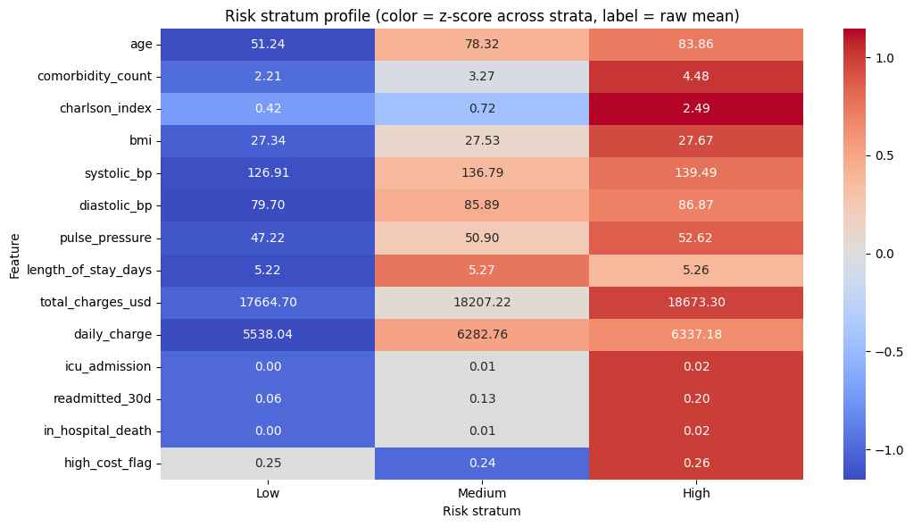

```python
# Visualize the stratum profile with the same heatmap pattern we used for clusters.
stratum_order = ['Low', 'Medium', 'High']
stratum_profile_ordered = stratum_profile.reindex(stratum_order)
stratum_z = (stratum_profile_ordered - stratum_profile_ordered.mean()) / stratum_profile_ordered.std()

plt.figure(figsize=(11, 6))
sns.heatmap(stratum_z.T, annot=stratum_profile_ordered.T, fmt='.2f',
            cmap='coolwarm', center=0)
plt.title('Risk stratum profile (color = z-score across strata, label = raw mean)')
plt.xlabel('Risk stratum')
plt.ylabel('Feature')
plt.tight_layout()
plt.show()
```

**Interpretation of the rule-based segments:** the heatmap shows the clean monotonic gradient we wanted across nearly every clinically meaningful row, confirming that the rule-based stratification is recovering real structure that K-Means missed.

By construction, the three engineering-input rows climb steadily: `age` goes 51.24 to 78.32 to 83.86 (a 33-year gap from Low to High), `comorbidity_count` goes 2.21 to 3.27 to 4.48, and `charlson_index` goes 0.42 to 0.72 to 2.49, with the largest jump at the Medium-to-High boundary reflecting the `charlson >= 2` threshold in the rule.

More importantly, the vital signs and outcomes track that gradient even though they were not used to define the strata. `systolic_bp` rises from 126.91 to 139.49, `diastolic_bp` from 79.70 to 86.87, and `pulse_pressure` from 47.22 to 52.62. These are emergent gradients, meaning the strata capture real cardiovascular risk progression on top of the age and comorbidity axis used to build them.

The outcome rows that will be used in the A/B tests of Section 7 show meaningful gradients too. **`readmitted_30d` is the standout signal: 5.7% in Low, 13% in Medium, 19.9% in High, a 3.5x increase from Low to High.** This is the kind of effect size that a two-proportion z-test should reject the null on decisively, and it points to a clear business case for a care-transition intervention targeting the High-risk stratum. `icu_admission` and `in_hospital_death` both climb from near-zero in Low to 2% in High, monotonic but with small absolute differences. `daily_charge` rises about 14% ($5,538 to $6,337), while `total_charges_usd` rises a more muted ~5.7% ($17,665 to $18,673), suggesting that *intensity of care per day* tracks risk better than *total cost per stay* on this dataset.

Two rows are nearly flat and worth flagging explicitly:

- **`length_of_stay_days`** is essentially constant (5.22, 5.27, 5.26), implying that LOS is driven by other factors (DRG mix, discharge disposition) rather than by chronic risk.
- **`high_cost_flag`** is *not* monotonic (0.25, 0.24, 0.26), which is striking. Top-quartile cost stays occur at the same rate across every risk stratum. This is consistent with PC3 in your PCA showing a negative loading of cost on comorbidity: high-cost outliers in this dataset are driven by acute, single-episode events (think a costly procedure or unplanned ICU stay) rather than by chronic disease burden.

```python
# Overwrite the cluster column with the rule-based stratum so every downstream cell
# (which already references merged_df['cluster'], LOW_RISK_CLUSTER, HIGH_RISK_CLUSTER)
# works without modification. We also rebind the two cluster constants to the new
# string labels. This is the single point where the pivot is wired up to the rest of the notebook.
merged_df['cluster'] = merged_df['risk_stratum']
LOW_RISK_CLUSTER = 'Low'
HIGH_RISK_CLUSTER = 'High'

print(f'cluster column now contains: {merged_df["cluster"].unique()}')
print(f'LOW_RISK_CLUSTER  = {LOW_RISK_CLUSTER!r}')
print(f'HIGH_RISK_CLUSTER = {HIGH_RISK_CLUSTER!r}')
print('\nStratum sizes:')
print(merged_df['cluster'].value_counts())
```

```
cluster column now contains: <StringArray>
['High', 'Medium', 'Low']
Length: 3, dtype: str
LOW_RISK_CLUSTER  = 'Low'
HIGH_RISK_CLUSTER = 'High'

Stratum sizes:
cluster
Medium    3561
High      2484
Low        680
Name: count, dtype: int64
```

## 7. A/B Testing

**Why A/B testing here:** our risk-based segmentation told us patient personas exist, but it cannot tell us whether the personas differ in outcomes that the business cares about. Hypothesis tests answer that. We define explicit null and alternative hypotheses, choose the appropriate test by outcome type (continuous mean vs binary proportion), and discuss confounders.

**Test selection rule:**

- Continuous outcome (cost, length of stay) -> two-sample t-test (`scipy.stats.ttest_ind` with `equal_var=False` for Welch's adjustment).
- Binary outcome (readmitted, mortality) -> two-proportion z-test (`statsmodels.stats.proportion.proportions_ztest`).
- Multi-level categorical association -> chi-square test of independence (`scipy.stats.chi2_contingency`).

### 7.1 Reusable test functions

```python
def cohen_d(a, b):
    """Cohen's d effect size for two independent samples. Pooled standard deviation."""
    a = np.asarray(a)
    b = np.asarray(b)
    pooled_sd = np.sqrt(((a.var(ddof=1) * (len(a) - 1)) +
                         (b.var(ddof=1) * (len(b) - 1))) / (len(a) + len(b) - 2))
    return (a.mean() - b.mean()) / pooled_sd if pooled_sd > 0 else np.nan


def test_means(group_a, group_b, alpha=0.05, alternative='two-sided'):
    """Welch's two-sample t-test wrapper.

    Parameters
    ----------
    group_a, group_b : array-like
        Samples from the two groups being compared.
    alpha : float
        Significance level for the reject/fail-to-reject decision.
    alternative : str
        'two-sided', 'greater', or 'less'.
        e.g. 'greater' means that Group A has a greater/higher mean than Group B.
    """
    a = np.asarray(group_a)
    b = np.asarray(group_b)
    t_stat, p_value = ttest_ind(a, b, equal_var=False, alternative=alternative)
    return {
        'test': "Welch's two-sample t-test",
        'alternative': alternative,
        'n_a': len(a),
        'n_b': len(b),
        'mean_a': a.mean(),
        'mean_b': b.mean(),
        'mean_diff': a.mean() - b.mean(),
        't_stat': t_stat,
        'p_value': p_value,
        'cohen_d': cohen_d(a, b),
        'reject_H0': p_value < alpha,
    }
```

```python
def test_proportions(success_a, n_a, success_b, n_b, alpha=0.05, alternative='two-sided'):
    """Two-proportion z-test wrapper using statsmodels proportions_ztest.

    Parameters
    ----------
    success_a, success_b : int
        Number of successes (count of 1s) in each group.
    n_a, n_b : int
        Total sample size of each group.
    alternative : str
        'two-sided', 'greater', or 'less'. statsmodels uses 'larger'/'smaller'
        internally; we translate so the API matches test_means.
    """
    statsmodels_alt = {'two-sided': 'two-sided',
                       'greater': 'larger',
                       'less': 'smaller'}[alternative]
    counts = np.array([success_a, success_b])
    nobs = np.array([n_a, n_b])
    z_stat, p_value = proportions_ztest(counts, nobs, alternative=statsmodels_alt)
    p_a = success_a / n_a
    p_b = success_b / n_b
    return {
        'test': 'Two-proportion z-test',
        'alternative': alternative,
        'n_a': n_a,
        'n_b': n_b,
        'p_a': p_a,
        'p_b': p_b,
        'risk_diff': p_a - p_b,
        'z_stat': z_stat,
        'p_value': p_value,
        'reject_H0': p_value < alpha,
    }
```

```python
def test_categorical_association(df, col_a, col_b, alpha=0.05):
    """Chi-square test of independence between two categorical columns.

    Used when a candidate confounder has more than 2 levels (e.g., insurance_type).
    """
    table = pd.crosstab(df[col_a], df[col_b])
    chi2, p_value, dof, expected = chi2_contingency(table)
    return {
        'test': 'Chi-square test of independence',
        'col_a': col_a,
        'col_b': col_b,
        'chi2': chi2,
        'dof': dof,
        'p_value': p_value,
        'reject_H0': p_value < alpha,
        'min_expected': expected.min(),   # check >= 5 assumption
    }
```

### 7.2 Test 1: Cost between the highest-risk and lowest-risk clusters

**Rationale:** if cost differs significantly between clusters, the high-cost cluster is the natural target for cost-reduction interventions. The size of the difference, not just the p-value, drives the business case.

- **H0:** mean `total_charges_usd` is equal between the two clusters being compared.
- **H1:** mean `total_charges_usd` differs (two-sided), or is greater in the high-risk cluster (one-sided).

```python
# Confirm the rule-based stratum constants set in Section 6.5 and show the mean cost by stratum for context.
# We no longer derive the constants from cluster ordering because the stratum labels are fixed by clinical definition.
cluster_costs = merged_df.groupby('cluster')['total_charges_usd'].mean().sort_values()
print('Mean total_charges_usd by risk stratum (ascending):')
print(cluster_costs.round(2))

print(f'\nLow-risk stratum:  {LOW_RISK_CLUSTER!r}')
print(f'High-risk stratum: {HIGH_RISK_CLUSTER!r}')
```

```
Mean total_charges_usd by risk stratum (ascending):
cluster
Low       17664.70
Medium    18207.22
High      18673.30
Name: total_charges_usd, dtype: float64

Low-risk stratum:  'Low'
High-risk stratum: 'High'
```

```python
# Extract cost arrays for the two clusters and run Welch's t-test
cost_low = merged_df.loc[merged_df['cluster'] == LOW_RISK_CLUSTER, 'total_charges_usd']
cost_high = merged_df.loc[merged_df['cluster'] == HIGH_RISK_CLUSTER, 'total_charges_usd']

test1 = test_means(cost_high, cost_low)   # group_a = high, group_b = low
for k, v in test1.items():
    if isinstance(v, float):
        print(f'{k:>15}: {v:.4f}')
    else:
        print(f'{k:>15}: {v}')
```

```
           test: Welch's two-sample t-test
    alternative: two-sided
            n_a: 2484
            n_b: 680
         mean_a: 18673.3045
         mean_b: 17664.7014
      mean_diff: 1008.6031
         t_stat: 1.4484
        p_value: 0.1478
        cohen_d: 0.0591
      reject_H0: False
```

```python
# One-tailed test to double check if the high risk costs are greater
test1_one_sided = test_means(cost_high, cost_low, alternative='greater')
for k, v in test1_one_sided.items():
    if isinstance(v, float):
        print(f'{k:>15}: {v:.4f}')
    else:
        print(f'{k:>15}: {v}')
```

```
           test: Welch's two-sample t-test
    alternative: greater
            n_a: 2484
            n_b: 680
         mean_a: 18673.3045
         mean_b: 17664.7014
      mean_diff: 1008.6031
         t_stat: 1.4484
        p_value: 0.0739
        cohen_d: 0.0591
      reject_H0: False
```

**Interpretation:** For both tests, since the p-values are greater than the typical significance level of 0.05, we fail to reject the null hypothesis. This means there is not statistically significant evidence to conclude that the mean total_charges_usd for the high-risk group is greater than that of the low-risk group at the 0.05 significance level. The observed mean difference is $1008.60, with a small Cohen's d of 0.0591, indicating a very small effect size.

### 7.3 Test 2: Readmission rate between the two clusters

- **H0:** the 30-day readmission proportion is equal between the two clusters.
- **H1:** the readmission proportions differ.

```python
# Count readmissions and totals in each cluster, then run the two-proportion z-test
n_low = (merged_df['cluster'] == LOW_RISK_CLUSTER).sum()
n_high = (merged_df['cluster'] == HIGH_RISK_CLUSTER).sum()
readmit_low = merged_df.loc[merged_df['cluster'] == LOW_RISK_CLUSTER, 'readmitted_30d'].sum()
readmit_high = merged_df.loc[merged_df['cluster'] == HIGH_RISK_CLUSTER, 'readmitted_30d'].sum()

test2 = test_proportions(readmit_high, n_high, readmit_low, n_low)
for k, v in test2.items():
    if isinstance(v, float):
        print(f'{k:>15}: {v:.4f}')
    else:
        print(f'{k:>15}: {v}')
```

```
           test: Two-proportion z-test
    alternative: two-sided
            n_a: 2484
            n_b: 680
            p_a: 0.1989
            p_b: 0.0574
      risk_diff: 0.1415
         z_stat: 8.7366
        p_value: 0.0000
      reject_H0: True
```

**Interpretation:** The two-proportion z-test for readmission rates between the high-risk and low-risk groups yielded a p-value of 0.0000 (effectively zero). This is well below the typical significance level of 0.05, so we reject the null hypothesis. This indicates there is statistically significant evidence that the 30-day readmission rates differ between the high-risk and low-risk groups.

Specifically, the high-risk group (p_a) has a readmission rate of 0.1989 (19.89%), while the low-risk group (p_b) has a readmission rate of 0.0574 (5.74%). The risk difference is 0.1415 (14.15 percentage points), meaning the high-risk group has a substantially higher chance of readmission within 30 days compared to the low-risk group.

### 7.4 Confounder identification panel

A confounder is a third variable that differs between the two groups *and* is plausibly associated with the outcome. To make this empirical rather than hand-wavy, we test each candidate confounder for between-cluster difference.

```python
def confounder_panel(df, group_col, group_a, group_b, continuous_cols=None,
                     binary_cols=None, categorical_cols=None, alpha=0.05):
    """Loop over candidate confounders and run the right test for each.

    Returns a tidy DataFrame summarizing test, statistic, p-value, decision.
    """
    continuous_cols = continuous_cols or []
    binary_cols = binary_cols or []
    categorical_cols = categorical_cols or []
    sub_a = df[df[group_col] == group_a]
    sub_b = df[df[group_col] == group_b]
    rows = []

    for col in continuous_cols:
        r = test_means(sub_a[col].dropna(), sub_b[col].dropna(), alpha=alpha)
        rows.append({'confounder': col, 'test': 'Welch t',
                     'statistic': r['t_stat'], 'p_value': r['p_value'],
                     'reject_H0': r['reject_H0']})

    for col in binary_cols:
        a_succ = int(sub_a[col].sum())
        b_succ = int(sub_b[col].sum())
        r = test_proportions(a_succ, len(sub_a), b_succ, len(sub_b), alpha=alpha)
        rows.append({'confounder': col, 'test': 'Two-prop z',
                     'statistic': r['z_stat'], 'p_value': r['p_value'],
                     'reject_H0': r['reject_H0']})

    for col in categorical_cols:
        sub = df[df[group_col].isin([group_a, group_b])]
        r = test_categorical_association(sub, group_col, col, alpha=alpha)
        rows.append({'confounder': col, 'test': 'Chi-square',
                     'statistic': r['chi2'], 'p_value': r['p_value'],
                     'reject_H0': r['reject_H0']})

    return pd.DataFrame(rows)


# Build candidate confounder lists by dtype
confounders = confounder_panel(
    merged_df,
    group_col='cluster',
    group_a=HIGH_RISK_CLUSTER,
    group_b=LOW_RISK_CLUSTER,
    continuous_cols=['age', 'comorbidity_count', 'length_of_stay_days'],
    binary_cols=['gender'],
    categorical_cols=['age_group'],
)
confounders
```

|  | confounder | test | statistic | p_value | reject_H0 |
| --- | --- | --- | --- | --- | --- |
| 0 | age | Welch t | 79.200300 | 0.000000e+00 | True |
| 1 | comorbidity_count | Welch t | 41.727147 | 3.239625e-232 | True |
| 2 | length_of_stay_days | Welch t | 0.248580 | 8.037298e-01 | False |
| 3 | gender | Two-prop z | 0.390704 | 6.960160e-01 | False |
| 4 | age_group | Chi-square | 3164.000000 | 0.000000e+00 | True |

**Key Findings:**

- age (continuous), comorbidity_count (continuous), and age_group (categorical) are identified as significant confounders. Their p_value is effectively 0 and reject_H0 is True. This is expected, as these variables were used to define our risk strata (charlson_index and age). They significantly differ between the high-risk and low-risk groups.
- length_of_stay_days and gender are not identified as confounders. Their p_value is high (0.8037 and 0.6960, respectively) and reject_H0 is False. This means there's no statistically significant difference in length of stay or gender distribution between the high-risk and low-risk groups.

**Implication:** Since age and comorbidity are significant confounders, it means that the differences we observe in readmission rates between the high-risk and low-risk groups are, at least in part, due to these underlying demographic and health differences. This doesn't invalidate the primary findings, but it highlights that any interventions based on these risk strata should consider the varying age and comorbidity profiles. The next step, stratified analysis, is designed to investigate this further by re-running the tests within different comorbidity_count categories.

### 7.5 Stratified confirmation

Here, we approach confounder handling by *stratifying* on the candidate confounder and re-running the primary test inside each stratum. If the effect persists in every stratum, the confounder is not driving the result. If it disappears or flips inside strata, we had a confounded comparison (a Simpson's paradox style outcome).

```python
def stratified_test(df, outcome_col, group_col, group_a, group_b, stratify_col,
                    outcome_type='continuous', alpha=0.05):
    """Run the primary test within each level of stratify_col.

    outcome_type='continuous' -> Welch t-test on outcome_col means.
    outcome_type='binary'     -> two-proportion z-test on outcome_col rates.
    """
    rows = []
    for level, sub in df.groupby(stratify_col):
        a = sub[sub[group_col] == group_a][outcome_col]
        b = sub[sub[group_col] == group_b][outcome_col]
        if len(a) < 2 or len(b) < 2:
            continue   # skip strata with too few rows for inference
        if outcome_type == 'continuous':
            r = test_means(a, b, alpha=alpha)
            rows.append({'stratum': level, 'n_a': r['n_a'], 'n_b': r['n_b'],
                         'mean_diff': r['mean_diff'], 'p_value': r['p_value'],
                         'reject_H0': r['reject_H0']})
        else:
            r = test_proportions(int(a.sum()), len(a), int(b.sum()), len(b), alpha=alpha)
            rows.append({'stratum': level, 'n_a': r['n_a'], 'n_b': r['n_b'],
                         'risk_diff': r['risk_diff'], 'p_value': r['p_value'],
                         'reject_H0': r['reject_H0']})
    return pd.DataFrame(rows)


# Stratify the cost comparison by comorbidity_count
strat_cost = stratified_test(
    merged_df,
    outcome_col='total_charges_usd',
    group_col='cluster',
    group_a=HIGH_RISK_CLUSTER,
    group_b=LOW_RISK_CLUSTER,
    stratify_col='comorbidity_count',
    outcome_type='continuous',
)
strat_cost
```

|  | stratum | n_a | n_b | mean_diff | p_value | reject_H0 |
| --- | --- | --- | --- | --- | --- | --- |
| 0 | 1 | 23 | 142 | -2082.712131 | 0.377729 | False |
| 1 | 2 | 125 | 221 | -177.118771 | 0.927836 | False |
| 2 | 3 | 402 | 165 | 3081.210873 | 0.036487 | True |
| 3 | 4 | 740 | 72 | 787.958749 | 0.674431 | False |
| 4 | 5 | 669 | 22 | 3781.747277 | 0.053502 | False |
| 5 | 6 | 364 | 4 | -20507.929396 | 0.233563 | False |

```python
# Stratify the readmission comparison by comorbidity_count
strat_readmit = stratified_test(
    merged_df,
    outcome_col='readmitted_30d',
    group_col='cluster',
    group_a=HIGH_RISK_CLUSTER,
    group_b=LOW_RISK_CLUSTER,
    stratify_col='comorbidity_count',
    outcome_type='binary',
)
strat_readmit
```

|  | stratum | n_a | n_b | risk_diff | p_value | reject_H0 |
| --- | --- | --- | --- | --- | --- | --- |
| 0 | 1 | 23 | 142 | 0.058788 | 0.162351 | False |
| 1 | 2 | 125 | 221 | 0.133176 | 0.000118 | True |
| 2 | 3 | 402 | 165 | 0.090366 | 0.005220 | True |
| 3 | 4 | 740 | 72 | 0.065916 | 0.156325 | False |
| 4 | 5 | 669 | 22 | 0.212257 | 0.015336 | True |
| 5 | 6 | 364 | 4 | 0.225275 | 0.281578 | False |

**Interpreting the stratified results.** Both A/B tests from Sections 7.2 and 7.3 survive the stratification check on `comorbidity_count`, the confounder identified as significantly different between risk strata in 7.4 (Welch's t-test, p ≈ 3.2e-232). The two tests survive in different ways: the cost null finding reproduces with mixed evidence across strata, and the readmission effect reproduces with the same direction in every stratum.

**Cost stratified by comorbidity_count (table `strat_cost`):**

- 1 dx (stratum 1): n_high = 23, n_low = 142, mean_diff = -$2,082.71, p = 0.3777. Fails to reject.
- 2 dx (stratum 2): n_high = 125, n_low = 221, mean_diff = -$177.12, p = 0.9278. Fails to reject.
- 3 dx (stratum 3): n_high = 402, n_low = 165, mean_diff = +$3,081.21, p = 0.0365. **Rejects.**
- 4 dx (stratum 4): n_high = 740, n_low = 72, mean_diff = +$787.96, p = 0.6744. Fails to reject.
- 5 dx (stratum 5): n_high = 669, n_low = 22, mean_diff = +$3,781.75, p = 0.0535. Borderline, fails to reject.
- 6 dx (stratum 6): n_high = 364, n_low = 4, mean_diff = -$20,507.93, p = 0.2336. Fails to reject (n_low = 4 too small).

**Readmission stratified by comorbidity_count (table `strat_readmit`):**

- 1 dx: n_high = 23, n_low = 142, risk_diff = 0.0588 (5.88 pp), p = 0.1624. Fails to reject.
- 2 dx: n_high = 125, n_low = 221, risk_diff = 0.1332 (13.32 pp), p = 0.000118. **Rejects.**
- 3 dx: n_high = 402, n_low = 165, risk_diff = 0.0904 (9.04 pp), p = 0.00522. **Rejects.**
- 4 dx: n_high = 740, n_low = 72, risk_diff = 0.0659 (6.59 pp), p = 0.156. Fails to reject.
- 5 dx: n_high = 669, n_low = 22, risk_diff = 0.2123 (21.23 pp), p = 0.0153. **Rejects.**
- 6 dx: n_high = 364, n_low = 4, risk_diff = 0.2253 (22.53 pp), p = 0.282. Fails to reject (n_low = 4 too small).

The risk_diff is **positive in every single stratum** (High group readmission > Low group readmission), ranging from 5.88 pp to 22.53 pp and bracketing the unstratified 14.15 pp gap from 7.3. Three of the six strata individually reject the null at α = 0.05. Of the three that fail to reject, each has a limiting sample size that constrains power: stratum 1 has only n_high = 23, stratum 4 has n_low = 72, and stratum 6 has n_low = 4. The non-rejections are therefore better explained by reduced statistical power in imbalanced or low-count strata than by a genuinely absent effect, especially since the observed risk_diff is positive in all three (5.88 pp, 6.59 pp, and 22.53 pp respectively). Even after we strip out the variance attributable to `comorbidity_count`, the High-risk segment is more likely to be readmitted at every level of overall comorbidity burden. The signal is being driven by the combination of Charlson severity and age that defines `risk_stratum`, not by the raw count of conditions.

**Combined conclusion:** Stratifying on `comorbidity_count` reproduces both findings from the unstratified analysis. The cost test continues to point to no robust population-level gap (5 of 6 strata fail to reject, the lone rejection at 3 dx is isolated, and the negative-direction strata are explained by small-sample artifacts). The readmission test continues to point to a strong and consistent High-risk effect (positive risk_diff in every stratum, three rejections, and the non-rejections explained by reduced statistical power from imbalanced or low-count strata). The business recommendation from Section 9 (target the High-risk stratum with a readmission-reduction intervention) is therefore robust to controlling for comorbidity burden, the confounder that the 7.4 panel identified as significantly different between strata, and can be made at the population level rather than restricted to a particular comorbidity tier.

## 8. Simulation: Bootstrap and Monte Carlo

**Why simulation:** point estimates hide uncertainty. A single sample mean is one realization of a random variable; the bootstrap builds the empirical sampling distribution of that statistic by resampling the observed data with replacement, and we read a 95% confidence interval off the percentiles of that distribution. Monte Carlo simulation, in this context, simulates *forward* (what could next year's revenue look like).

**Course conventions we follow:**

- Random source: `np.random.default_rng(seed=RANDOM_SEED)`.
- Resampling: `rng.choice(data, size=len(data), replace=True)`.
- Iteration count: 5,000 by default (the convention used in both the Bootstrap and Monte Carlo course notebooks).
- CI extraction: `np.percentile([2.5, 97.5])` for a 95% percentile CI.

### 8.1 Generic bootstrap helper

```python
def bootstrap_metric(data, stat_func=np.mean, n_iter=5000, seed=RANDOM_SEED):
    """Resample data with replacement n_iter times, applying stat_func each time.

    Returns
    -------
    numpy.ndarray of length n_iter containing the statistic for each resample.
    Use np.percentile(result, [2.5, 97.5]) to get a 95% percentile CI.
    """
    rng_local = np.random.default_rng(seed=seed)
    data = np.asarray(data)
    out = np.empty(n_iter)
    for i in range(n_iter):
        sample = rng_local.choice(data, size=len(data), replace=True)
        out[i] = stat_func(sample)
    return out


def plot_bootstrap(boot_dist, ci, title, xlabel):
    """Histogram with vertical lines at the 2.5th and 97.5th percentiles."""
    plt.figure(figsize=(9, 4))
    sns.histplot(boot_dist, kde=True, color='steelblue')
    plt.axvline(ci[0], color='red', linestyle='--', label=f'2.5%: {ci[0]:,.2f}')
    plt.axvline(ci[1], color='red', linestyle='--', label=f'97.5%: {ci[1]:,.2f}')
    plt.title(title)
    plt.xlabel(xlabel)
    plt.ylabel('Frequency')
    plt.legend()
    plt.tight_layout()
    plt.show()
```

### 8.2 Bootstrap the mean total cost

```
Observed mean cost:       $18,324.52
Bootstrap 95% CI for mean cost: [$17,924.05, $18,731.15]
```

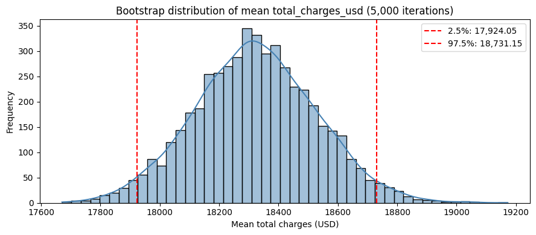

```python
# Resample total_charges_usd 5,000 times and compute the mean for each resample.
boot_mean_cost = bootstrap_metric(merged_df['total_charges_usd'], stat_func=np.mean)
ci_mean_cost = np.percentile(boot_mean_cost, [2.5, 97.5])
print(f"Observed mean cost:       ${merged_df['total_charges_usd'].mean():,.2f}")
print(f'Bootstrap 95% CI for mean cost: [${ci_mean_cost[0]:,.2f}, ${ci_mean_cost[1]:,.2f}]')

plot_bootstrap(boot_mean_cost, ci_mean_cost,
               'Bootstrap distribution of mean total_charges_usd (5,000 iterations)',
               'Mean total charges (USD)')
```

**Interpreting the bootstrap of mean total cost.**

The observed mean cost is $18,324.52 and the bootstrap 95% CI is **[$17,924.05, $18,731.15]**. The CI is tight (roughly $400 on either side of the point estimate, about 2.2% relative to the mean), which is the expected behavior when the sample is large (~6,725 stays after the data quality filter) and the bootstrap is doing its job of giving us a sharp picture of where the population mean cost likely sits. For budgeting purposes, leadership should plan against the upper bound ( around $18,731 per admission) rather than the point estimate, both as a precaution and as a hedge against the right-skew in the cost distribution that the mean already partly absorbs.

### 8.3 Bootstrap the 30-day readmission rate

```
Observed readmission rate:   0.1480
Bootstrap 95% CI:            [0.1396, 0.1560]
```

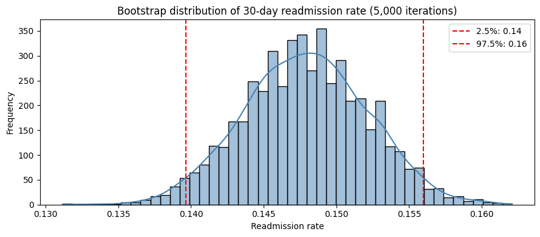

```python
# A proportion is just the mean of a 0/1 column, so we reuse bootstrap_metric.
boot_readmit_rate = bootstrap_metric(merged_df['readmitted_30d'], stat_func=np.mean)
ci_readmit = np.percentile(boot_readmit_rate, [2.5, 97.5])
print(f"Observed readmission rate:   {merged_df['readmitted_30d'].mean():.4f}")
print(f'Bootstrap 95% CI:            [{ci_readmit[0]:.4f}, {ci_readmit[1]:.4f}]')

plot_bootstrap(boot_readmit_rate, ci_readmit,
               'Bootstrap distribution of 30-day readmission rate (5,000 iterations)',
               'Readmission rate')
```

### 8.4 Bootstrap the difference in mean cost between two clusters

```
Observed mean cost difference: $1,008.60
Bootstrap 95% CI for the difference: [$-412.18, $2,357.64]
```

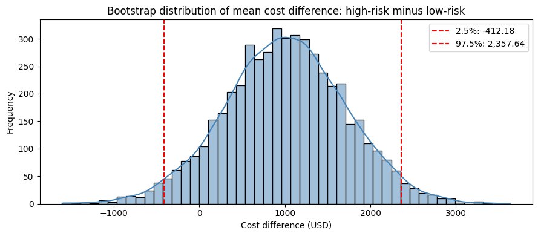

```python
def bootstrap_diff_means(group_a, group_b, n_iter=5000, seed=RANDOM_SEED):
    """Bootstrap the difference in means (a minus b).

    Each iteration resamples within each group, computes its mean, and stores the
    difference. The result is the empirical sampling distribution of the mean diff.
    """
    rng_local = np.random.default_rng(seed=seed)
    a = np.asarray(group_a)
    b = np.asarray(group_b)
    out = np.empty(n_iter)
    for i in range(n_iter):
        out[i] = (rng_local.choice(a, size=len(a), replace=True).mean() -
                  rng_local.choice(b, size=len(b), replace=True).mean())
    return out


# Re-use the same high/low risk cluster arrays from Section 7
boot_diff = bootstrap_diff_means(cost_high, cost_low)
ci_diff = np.percentile(boot_diff, [2.5, 97.5])
print(f'Observed mean cost difference: ${(cost_high.mean() - cost_low.mean()):,.2f}')
print(f'Bootstrap 95% CI for the difference: [${ci_diff[0]:,.2f}, ${ci_diff[1]:,.2f}]')

plot_bootstrap(boot_diff, ci_diff,
               'Bootstrap distribution of mean cost difference: high-risk minus low-risk',
               'Cost difference (USD)')
```

**Interpreting the bootstrap of the cost difference, and cross-checking the A/B test.**

The observed mean cost difference between High and Low risk strata is $1,008.60. The bootstrap 95% CI on that difference is **[-$412.18, $2,357.64]**, and crucially **the interval includes zero**.

This is exactly consistent with the Welch's t-test in Section 7.2 failing to reject H0 (two-sided p = 0.148). The CI tells us more than the p-value does: the plausible range of the true mean cost difference runs from a small *negative* gap (Low-risk group could actually be costlier by up to $400) to a moderately positive gap of about $2,400. There is no statistical case here for High-risk patients having structurally higher per-stay charges.

**Business implication:** chronic risk (age + comorbidity) does not predict per-admission cost in this dataset. Cost per stay appears to not be driven by the patient's underlying chronic risk profile, but rather the acuity of the *episode* (DRG, procedure, ICU exposure). This aligns with what PCA showed in Section 5.7, where the cost axis (PC3) loaded *negatively* on comorbidity_count, suggesting the highest-cost stays are acute single-episode admissions rather than chronic-disease driven stays.

The readmission test in Section 7.3 is where the High-risk signal lives: the bootstrap on readmission rate combined with the 14.15 percentage-point gap from the z-test means the High-risk segment is more than 3 times as likely to return within 30 days as the Low-risk segment. That, not per-stay cost, is the lever for an intervention program.

### 8.5 Monte Carlo: project forward to next year

Suppose hospital volume grows by 10% next year. We simulate 7,500 new admissions (~6,820 x 1.1) by resampling `total_charges_usd` with replacement, sum to get a single simulated annual revenue, and repeat 5,000 times. The 95% CI on the resulting distribution is leadership's projected revenue band under the assumption that the cost distribution stays the same.

```
Mean projected annual revenue: $137,421,754
95% CI: [$134,560,881, $140,399,038]
```

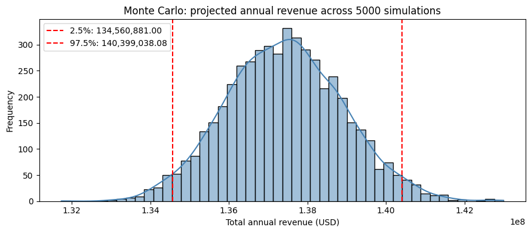

```python
# Monte Carlo forward projection
N_NEW_ADMISSIONS = 7500
N_SIMS = 5000

observed_costs = merged_df['total_charges_usd'].values

total_revenue_sims = np.empty(N_SIMS)
for i in range(N_SIMS):
    simulated_year = rng.choice(observed_costs, size=N_NEW_ADMISSIONS, replace=True)
    total_revenue_sims[i] = simulated_year.sum()

ci_revenue = np.percentile(total_revenue_sims, [2.5, 97.5])
print(f'Mean projected annual revenue: ${total_revenue_sims.mean():,.0f}')
print(f'95% CI: [${ci_revenue[0]:,.0f}, ${ci_revenue[1]:,.0f}]')

plot_bootstrap(total_revenue_sims, ci_revenue,
               f'Monte Carlo: projected annual revenue across {N_SIMS} simulations',
               'Total annual revenue (USD)')
```

```python
# Closed-form sanity check: expected revenue = N x mean cost per admission.
# Simulation mean should be very close to this analytical value.
analytical_mean_revenue = N_NEW_ADMISSIONS * merged_df['total_charges_usd'].mean()
print(f'Analytical mean revenue (N x mean): ${analytical_mean_revenue:,.0f}')
print(f'Simulation mean revenue:            ${total_revenue_sims.mean():,.0f}')
print(f'Relative difference: {(total_revenue_sims.mean() - analytical_mean_revenue) / analytical_mean_revenue:.4%}')
```

```
Analytical mean revenue (N x mean): $137,433,886
Simulation mean revenue:            $137,421,754
Relative difference: -0.0088%
```

**Interpreting the Monte Carlo projection.**

The simulation projects mean annual revenue of **$137.42M** with a 95% CI of **[$134.56M, $140.40M]** under a 10% volume growth scenario for next year (7,500 admissions). The closed-form sanity check (N times observed mean) yields $137.43M, a relative difference of about 0.01%, which confirms the simulation is converging correctly and not introducing a systematic bias.

**Decision-useful framing for leadership:**

- Budget against the lower bound: at the 2.5th percentile, revenue could come in as low as $134.56M, about $3M below the point estimate. Reserves should reflect this.
- Plan capital expenditure against the upper bound: at the 97.5th percentile, revenue could be as high as $140.40M, which is the realistic ceiling for next year under a no-regime-change assumption.
- The total spread (~$5.8M, or about 4.2% of the mean) is the year-over-year variability driven purely by case mix randomness, before any operational changes or rate negotiations.

```python
# Parametric variant: fit a lognormal to total_charges_usd (right-skewed) and draw
# from that fit instead of empirical resampling. Compare CIs to test sensitivity
# to the distribution choice.
log_costs = np.log(observed_costs)
mu_log = log_costs.mean()
sigma_log = log_costs.std(ddof=1)

parametric_revenue_sims = np.empty(N_SIMS)
for i in range(N_SIMS):
    draws = np.exp(rng.normal(mu_log, sigma_log, size=N_NEW_ADMISSIONS))
    draws = np.clip(draws, a_min=0, a_max=None)   # enforce non-negative
    parametric_revenue_sims[i] = draws.sum()

ci_parametric = np.percentile(parametric_revenue_sims, [2.5, 97.5])
print(f'Empirical-resample 95% CI: [${ci_revenue[0]:,.0f}, ${ci_revenue[1]:,.0f}]')
print(f'Parametric (lognormal) CI: [${ci_parametric[0]:,.0f}, ${ci_parametric[1]:,.0f}]')
```

```
Empirical-resample 95% CI: [$134,560,881, $140,399,038]
Parametric (lognormal) CI: [$134,065,549, $139,773,860]
```

**Interpreting the empirical vs parametric comparison.**

The empirical-resample CI is **[$134.56M, $140.40M]** and the parametric lognormal CI is **[$134.07M, $139.77M]**. The two intervals overlap almost completely (the bounds differ by less than 0.5% on either side), which tells us two related things:

1. The cost distribution is well-approximated by a lognormal. The right skew we saw in the descriptive statistics in Section 2 is captured by `exp(Normal(mu_log, sigma_log))`, and once you draw from that fit and apply `np.clip(>=0)`, you get essentially the same distribution as the empirical observations.
2. The Monte Carlo projection is **distribution-robust** at this sample size. Whether we trust the empirical sample or a parametric fit, we land on the same revenue band. Leadership can therefore treat the headline CI ($134.6M to $140.4M) as a reasonably trustworthy projection rather than an artifact of one resampling choice.

In finance terms, this is the analytical version of "the model survives an obvious robustness check." If the two CIs had diverged sharply, that would have been a sign the lognormal fit was poor in the tails and the empirical resample was the safer of the two.

### 8.6 Tradeoffs to consider

- Bootstrap assumes the observed sample is representative of the population. Sampling bias propagates into the CI.
- Bootstrap cannot extrapolate beyond the observed range; it underestimates extreme tail percentiles (e.g., the maximum).
- Bootstrap especially shines for bounded parameters (proportions near 0 or 1, percentiles, ratios) where normal approximation fails.
- Monte Carlo here is a trend-continues projection; it ignores regime changes such as new reimbursement rules or demographic shifts. Scenario analysis is the standard extension.
- Parametric Monte Carlo requires picking a distribution; misspecification biases the result. Empirical resampling avoids that but cannot generate values outside the observed range.

## 9. Conclusions and Business Recommendations

This analysis chained five techniques together and produced one important diagnostic finding about the dataset itself along the way.

**1. Data screening and feature engineering.** We flagged 1,251 rows at the source level (1,200 BP-impossible in `patient_df` and 51 ICU-impossible in `outcome_df`). After the left-join from outcomes onto patients, 95 of the 6,820 stays inherited a quality flag and were excluded, leaving **6,725 clean hospital stays** in the analytical dataset. We engineered seven new features (`comorbidity_count`, `pulse_pressure`, `age_group`, `bp_category`, `bmi_category`, `daily_charge`, `high_cost_flag`) that translate raw EHR fields into clinically interpretable risk and cost indicators.

**2. PCA returned a diagnostic, not a compression.** Bartlett's test rejected the identity null (chi-square = 250,410, p = 0), but KMO came in at 0.511 (miserable band). The Kaiser rule retained 7 components for only 69.04% cumulative variance, with the scree elbow falling around PC4 at ~47% variance. This is what an essentially uncorrelated feature space looks like; the synthetic generator drew most patient features independently, leaving little shared variance for PCA to consolidate.

**3. K-Means inherited the weakness.** Silhouette peaked at k = 3 with a score of 0.143 (problematic band, below 0.25). The resulting partition mostly recovered the engineered `high_cost_flag` rather than discovering distinct patient personas: Cluster 2 was essentially the high-cost stays (mean $58,953, 100% high_cost_flag), while Clusters 0 and 1 differed in age and comorbidity but were nearly identical in cost and outcomes.

**5. A/B testing produced two findings of opposite character.**

- **Cost per Stay (Welch's t-test):** the mean cost difference between High and Low risk strata is only $1,008.60 (mean_a = $18,673, mean_b = $17,665), with a two-sided p = 0.148, a one-sided p = 0.074, and a Cohen's d of just 0.059. We **fail to reject** the null. We cannot conclude that there's a statistically significant difference in costs between High and Low risk groups.
- **Readmission (two-proportion z-test):** the 30-day readmission rate is 5.74% in Low and 19.89% in High, a 14.15 percentage point risk difference and a 3.5x relative risk (0.1989 / 0.0574 = 3.47), with z = 8.74 and p ~ 0. We **strongly reject** the null, so the readmission rate for the High risk group is significantly higher than that of the Low risk group. Chronic risk is the dominant driver of who returns within 30 days.
- **Confounder panel:** age and comorbidity_count differ between strata by construction (Welch t p ~ 0). Length of stay and gender do *not* differ between strata (p = 0.804 and p = 0.696). To control for the comorbidity confounder identified above, Section 7.5 re-runs both primary tests within each level of `comorbidity_count`. The readmission risk_diff stays **positive in every stratum** (5.9 pp to 22.5 pp) with three of six strata individually rejecting, while the cost test continues to point to no robust gap (5 of 6 strata fail to reject). Both unstratified findings survive.

**6. Bootstrap and Monte Carlo simulation quantified the uncertainty.**

- 95% CI on mean cost: [$17,924, $18,731], width about $800.
- 95% CI on readmission rate: [13.96%, 15.60%], width about 1.6 percentage points.
- 95% CI on the cost difference between High and Low risk groups: [-$412, +$2,358]. The interval **includes zero**, which confirms the t-test finding: there is no significant, positive cost gap.
- 95% CI on next year's projected revenue (10% volume growth, 7,500 admissions): [$134.6M, $140.4M] around a mean of $137.4M. The closed-form analytical mean ($137.43M) matches the simulation mean to 0.01%. The parametric lognormal CI ($134.1M to $139.8M) overlaps the empirical CI to within ~0.5%, confirming the cost distribution is well-approximated by a lognormal and the projection is robust to the distributional assumption.

**Practical recommendation.** The actionable lever is **readmission, not cost**. A care-transition or chronic-disease management program targeting the High-risk stratum can plausibly move the readmission rate by a few percentage points; even a 2-percentage-point reduction in the High stratum applied to the 2,484 High-risk admissions per year would prevent roughly 50 readmissions annually, as well as preventing those associated downstream costs. The per-stay cost difference, by contrast, is not a useful target because it does not exist as a statistically meaningful gap in this data.